# Engine Design Part 1

**Engine Design Part 1:** *Engine Parameter Selection and Contour Sizing*: By Saaketh Ramoju

### Preface

This guide is meant to be a very high level walkthrough on choosing your overarching engine parameters, assessing your engine efficiencies, and designing an engine contour (the internal shape of the thrust chamber assembly) from these parameters. Obviously, engine design is a very deep rabbit hole that could go on and on forever, but there are some concepts that are universal to every LRE (Liquid Rocket Engine) design process. This guide does not cover any heat transfer analysis or manufacturing methods (maybe I will in another part). I also assume you know some basic thermodynamics and fluids topics, including isentropic flow and conservation equations; if you're not already familiar with that stuff, consider checking out Professor Seitzman's AE 2010 slides:

https://seitzman.gatech.edu/classes/ae2010/

Additionally, this guide, relevant accesible formats, and a document on $c^*$ and $C_{\tau}$ area posted in this repository:

https://github.com/saakethramoju/Engine-Design-Guide

I hope you find this notebook helpful!

1. Imports and Initialization
   - Package Installations
   - Imports
   - Checks and Initialization
2. What are our Primary Engine Parameters
   - Chemical Equilibrium Theory
     - Atom Balances
     - Conservation of Energy
     - Formation Reactions, $K_p$ and Gibbs Functions
3. Adiabatic Flame Temperature
   - Equivalence Ratio
   - $T_c$ vs $P_c$
   - $MR_{T_{max}}$ vs $P_c$
4. Specific Heat and Exhaust Molecular Weights
5. $C^{*}$ and $C^{*}_{eff}$
6. $C_{\tau}$, Thrust Coefficient
7. Relating $C^*$ and $C_{\tau}$ to Thrust and Mass Flow Rate
   - Ideal Case ($C^*_{eff} = 100\%$)
   - $C^*_{eff} = 85\%$
8. $I_{sp}$, Specific Impulse
9. $I_{sp}$ and $\tau$ for Varying Ambient Conditions
   - What function (NASA CEA vs RocketCEA) gives the most realistic $I_{sp}$ and how does it inform nozzle design?
   - Thrust vs. $P_e$
   - What should our $P_e$ be and which set of ambient conditions should we use for design?
     - Flow Separation
10. Optimal MR vs Chamber Pressure
    - Equilibrium or Frozen?
    - Optimum Mixture Ratio as a function of $P_c$
    - Fully Equilibrium
    - $NFZ = 1$, Frozen from Chamber
    - $NFZ = 2$, Frozen from the Throat
11. Preliminary $MR$ Selection
12. Efficiencies
    - Chamber Efficiencies
    - Nozzle Efficiencies
    - $C_d$, Discharge Coefficient
    - Finite Area Combustors
13. Contour Design Process
    - $R_t$, Throat Radius
    - Converging Section
    - Combustion Chamber
      - $L^*$, Characteristic Length
      - Constraints and Optimization
    - Diverging Section
      - $MR$ vs $\epsilon$
      - $P_c$ vs $\epsilon$
      - De Laval Nozzles and The Method of Characteristics
      - Conical Nozzles
      - Bell Nozzles
14. Summary
15. Sources

# Imports and Initialization

If you're having trouble running this code, I would suggest checking your numpy, scipy, or matplotlib installations. If you're running this in VSCode and having issues with the code, then simply try uninstalling the Jupyter extensions and reinstalling them. The other alternative is to just uninstall VScode and reinstall. You can also try *pip3 uninstall rocketcea* and then rerun the code again.

**AVOID** restarting the kernel, for some reason it screws everything up. If you accidentally do, restart the your coding environment and then run a rocketCEA function (e.g. print(*rocket.get_eps_at_PcOvPe(400, 2.2, 50, 1, 0))*) after the rocket definition. The code in the *Efficiencies* section usually works after a restart, so run a code block there and then try running all of the code blocks after.

For reference, I am running this code on my local Python 3.13.2. You can also use a virtual environment in VSCode.

In general, Google Colab is the ideal Jupyter environment, but because the server is remote, code execution takes a little longer. You also only get two processors by default. That being said, if you have any issues with VSCode, Google Colab is another great place to run the code.

### Package Installations

These packages need to be installed in order for this notebook to operate

```python
# the "> /dev/null 2>&1" at the end of each line simply suppresses the
# installation log
!pip3 install rocketcea > /dev/null 2>&1
# in case it's not installed already (will be used to model NASA CEA)
!pip3 install rocketisp > /dev/null 2>&1
# used to model chamber and nozzle losses
!pip3 install ambiance > /dev/null 2>&1
# this is the standard atmosphere model that we will use
# later in the notebook
!pip3 install cantera > /dev/null 2>&1
# thermophysical, fluids, and kinetics toolbox
!pip3 install ipywidgets > /dev/null 2>&1
# for the engien design widget at the end
```

### Imports

All of the imports you see here will be used at some point in the guide.

```python
from rocketcea.cea_obj_w_units import CEA_Obj
import numpy as np
import matplotlib.pyplot as plt
from ambiance import Atmosphere
import multiprocessing
from rocketisp.rocket_isp import RocketThruster
from rocketisp.geometry import Geometry
from rocketisp.stream_tubes import CoreStream
from rocketisp.efficiencies import Efficiencies
from rocketisp.nozzle.nozzle import Nozzle
from rocketisp.geometry import solidCylVol, solidFrustrumVol
from scipy.optimize import minimize
from scipy.optimize import fsolve
from scipy.interpolate import griddata
import ipywidgets as widgets
from IPython.display import display
import cantera as ct
from PIL import Image
import csv
```

### Checks and Initialization

Let's check to see how many processors you have so that you can keep your computer form using all of them when running the code but also use enough to make the code faster.

```python
print(f"You have {multiprocessing.cpu_count()} processors")
```

```
You have 8 processors
```

It would be a good idea to familiarize yourself with the RocketCEA documentation:

https://rocketcea.readthedocs.io/en/latest/functions.html

And also the RocketIsp documentation:

https://rocketisp.readthedocs.io/en/latest/functions.html

The following code represents the rocket object I will use for essentially every code block in the notebook. It is essential that you run this code before moving on.

```python
rocket = CEA_Obj(oxName='LOX', fuelName='RP-1', temperature_units='degK',
                 cstar_units='m/sec', specific_heat_units='kJ/kg degK',
                 sonic_velocity_units='m/s', enthalpy_units='J/kg',
                 density_units='kg/m^3')
# This rocket object will be used going forward
# This initialization assumes an inifite area combustor.
# This is will later be changed
```

# What are our Primary Engine Parameters?

In order to start designing an engine, a few important parameters have to have to be established. Some of these have to decided early on since they inform the construction of the whole vehicle, and others can be tweaked as the analysis goes along. Here the ones you should care about when it comes to preliminary sizing:

- **$\tau$, Thrust**: This is not necessarily the thrust that the engine will produce during the entire flight but rather the thrust produced at maximum efficiency, which is when the flow out through the nozzle is perfectly expanded. More on this in the *Isp for Varying Ambient Conditions* section
- **$P_c$, Chamber Pressure**: Although it might seem like this should be a function of mass flow or something else, chamber pressure is something you get to choose. Very roughly speaking, for a given nozzle, a desired thrust is easier to reach with a higher chamber pressure. The opposite is also true: for a lower pressure, you need a bigger,better nozzle to get a higher thrust ($\tau = C_{\tau} * A_t * P_c$). There are a lot of considerations that go into choosing this value with the primary one being your feed system architecture. If you have a pressure-fed system, you're going to need much higher COPV pressures to sustain a higher Pc. With electric pumps, gas generators, etc. it's a lot easier to get higher pressures. This one should be chosen pretty early on as it will determine the necessary feed system, your injector stiffness, and tank sizes.
- **$P_e$, Exit Pressure**: This is pressure that the gases exit the nozzle with, NOT the outside ambient pressure. This one is usually chosen based on thrust level curve simulations of your flight, but it can also inform some of the other parameters in this list as well. Exit pressure determines how over or underexpanded your nozzle is, which affect your sea-level thrust and also the weight of your engine. More on this in the *Isp for Varying Ambient Conditions* and *Optimal MR vs Chamber/Exit Pressure* sections.
- **$MR$, Mixture Ratio**: As we normally define it, it's the ratio of mass flow rates of the oxidizer to fuel. This one needs to be chosen really early on since it greatly determines your tank sizes and pump flow rates. Moreover, $MR$ plays a huge role in determining how hot your engine will get, which will inform your engine material selection and sealing. This one requires a good amount of work to determine, and most of this notebook will be dedicated to optimizing $MR$ from an efficiency standpoint, not a materials and cooling standpoint.

There are certainly many other efficiency-related and geometric nozzle parameters you can tweak, but these are the primary ones to start with.

The next few sections will deal with choosing $MR$

# Chemical Equilibrium

Calculating combustion chamber temperatures from $P_c$ and $MR$ is not something that can be done easily by hand. In fact, it takes solving a system of nonlinear equations and several atom balances to find the *equilibrium* temperature. A computer, however, is quite good at doing this, and I would encourage anyone who is interested to try and write their own code to solve for final temperature and product composition given $P_c$ and $MR$. If you're interested in implementing your own chemical equilibrium code, check out Professor Seitzman's guide:

https://seitzman.gatech.edu/classes/ae6765/GenlSolutionChemicalEquilibrium.pdf

For the majority of this notebook, I will use *NASA CEA* or *Chemical Equilibrium with Applications*, a NASA legacy software that iterates through a bunch of temperatures to find the correct final temperature and composition. *RocketCEA* is a python library that allows us to use the results of CEA directly in our code, and it's the library I will be using to demonstrate the parameter selection. The following code uses RocketCEA's in-built CEA functions to establish a relation between chamber pressures and temperatures.

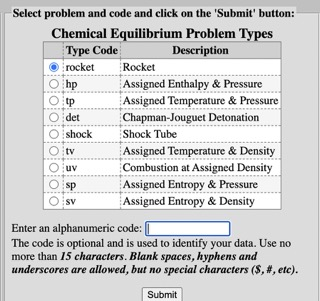

If you want to know more about combustion theory and kinetics, I recommend the following sources:

- Professor Seitzman's 6765, Kinetics and Thermodynamics of Gases, Lecture Notes: https://seitzman.gatech.edu/classes/ae6765/
- Professor Seitzman's 6766, Combustion, Lecture Notes: https://seitzman.gatech.edu/classes/ae6766/
- *Introduction to Physical Gas Dynamics*: Walter G. Vencenti & Charles H. Krueger, Jr

### Chemical Equilibrium Theory

Much like a lot of the thermodynamics we do, implementing chemical equilbrium really just comes down to mass and energy conservation. I think this is best demostrated through an example. Let's take, for example, the fuel used in the Raptor Engine: methane, $CH_4$. We shall react this substance with LOX, $O_2$. Let us first write out the stoichiometric reaction, which is defined to be a complete combustion at standard pressure and temperature:

$CH_4 + 2O_2 \leftrightharpoons CO_2 + 2H_2O$

Because $CO_2$ and $H_2O$ require the lowest *enthalpies of formation* at conditions that we are used to, they are what tend to form during complete combustion. However, as soon as there are excess molecules of the reactants or the temperature and pressure change, we will start to get many *minor* species.

$CH_4 + 2O_2 \leftrightharpoons CO_2 + H_2O + $ (many minor species)

Notice that we could not balance this reaction. That is because we do not know what the starting conditions are nor do we know what the final composition is. This is the essence of chemical equilibrium calculations: we try different ending compositions until one works.

Let's define our problem a little better. Let's say that we are reacting methane and LOX isobarically at 5100 psia, where the inlet temperatures of the $CH_4$ and LOX are 110 K and 90 K, respectively (obviously these are not what the Raptor chamber conditions are, but with staged combustion engines, finding the exact pressures is difficult. However, if the system is assumed to be adiabatic from the tank to the combustion chamber, using the cryo starting conditions is fine since the total energy is conserved). We can safely assume that all of the fuel vaporizes and gets used up. So that leaves us with the following *conversion reaction*, the one-way reaction formula that depicts all of the starting and ending species:

$\phi CH_4 + 2O_2 \rightarrow CO_2 + H_2O + CO + OH + H_2 + O_2 + $ (many minor species)

$\phi$ here represents the *equivalence ratio*, the ratio that compares the amount of fuel we actually have over the amount of fuel needed to have a stoichiometric reaction, so $\phi$ would be $1$ for stoich. Also notice that we have $O_2$ is on both sides of the reaction; this is helpful in case we have excess oxidizer left over, so that way, it will also show up in the final composition after our analysis. We assumed that essentially all of the fuel will be used, which is why $CH_4$ doesn't show up with the other products.

#### Atom Balances

We know the pressure and temperature of the reactants as well as what species are reacting. We also know the final pressure and what elements are present in the reaction: $C$, $H$, and $O$. Is this enough information to solve the problem? Let's first simplify our reaction a little (for the sake of explanation), and we will see.

$\phi CH_4 + 2O_2 \rightarrow n_{CO_2}CO_2 + n_{H_2O}H_2O + n_{CO}CO$

Obviously, those aren't the only species that show up, but this will get the idea across. Now we must conserve the number of atoms on either side of the reaction using *atom balances*.

Carbon: $n^C = \phi = n_{CO_2} + n_{CO}$

Hydrogen: $n^H = 4\phi = 2n_{H_2O}$

Oxygen: $n^O = 4 = 2n_{CO_2} + n_{H_2O} + n_{CO}$

If our goal is to solve for the composition wih $n_{CO_2}$, $n_{H_2O}$, and $n_{CO}$, these three linear equations need to be solvable. That means we have to know what $\phi$ is in order to find a final composition. We will have to define what $\phi$ is moving forward. Let's say our rocket has a mixture ratio of 3.6 (same as Raptor). What is the equivalence ratio?

```python
gas = ct.Solution('gri30.yaml')
fuel = 'CH4:1'
oxidizer = 'O2:1'
MR = 3.6
# cantera defines MR as fuel/ox
gas.set_mixture_fraction(1/(1+MR), fuel, oxidizer)
phi = gas.equivalence_ratio(fuel, oxidizer, basis='mole')
print(f"Equivalence Ratio = {phi:.2f}")
```

```
Equivalence Ratio = 1.11
```

Since $\phi = 1.11$, the reactant is considered to be *fuel-rich* since there is relatively more fuel than in the stoichiometric reaction. It looks like we now have enough information create a well-defined problem with solveable atom balances.

$n^C = 1.11 = n_{CO_2} + n_{CO}$

$n^H = 4.44 = 2n_{H_2O}$

$n^O = 4 = 2n_{CO_2} + n_{CO} + n_{H_2O}$

While we could proceed from here, we usually generalize the solution by solving for *mole fractions* instead of moles directly.

$\frac{n^C}{n^H} = 0.25 = \frac{n_{CO_2} + n_{CO}}{2n_{H_2O}} = \frac{\chi_{CO_2} + \chi_{CO}}{2\chi_{H_2O}}$

$\frac{n^H}{n^O} = 1.11 = \frac{2n_{H_2O}}{2n_{CO_2} + n_{CO} + n_{H_2O}} = \frac{2\chi_{H_2O}}{2\chi_{CO_2} + \chi_{CO} + \chi_{H_2O}}$

Our third, "missing" equation will come from the fact that

$\chi_{CO_2} + \chi_{CO} + \chi_{H_2O} = 1$

All three of these equations can still be solved as linear equations, which is convenient. We have three equations and three unknowns, so let's solve this system.

```python
#        0      1      2
# X = [X_CO2, X_CO, X_H2O]
def linear_equations(X):
    eq1 = np.sum(X) - 1
    eq2 = X[0] + X[1] - 0.5*X[2]
    eq3 = 2.22*X[0] + 1.11*X[1] + 1.11*X[2] - 2*X[2]
    return [eq1, eq2, eq3]

X0 = [1, 1, 1]
X = fsolve(linear_equations, X0)
print(f"CO2: {X[0]*100:.2f}%, CO: {X[1]*100:.2f}%, H2O: {X[2]*100:.2f}%")
```

```
CO2: 20.12%, CO: 13.21%, H2O: 66.67%
```

Already, without solving any nonlinear equations or iterations, we have a pretty good guess of what our final composition is. Notice that we were able to solve these equations fully linearly because we had exactly as many equations as we did the number of atoms participating in the reaction. In solving this, we used what is called the *Major-Minor Model*: we found the major constituents of the equilibrium mixture using simple, linear, atom balances. These major species are what will decompose to create the minor species. We can now use this as a starting guess to find the minor species.

#### Conservation of Energy

In the problem we defined, we have a prescribed a pressure at the final state, but nothing else. Our goal is to find the ending composition, but in order to do that, we need the final temperature (if you recall the state postulate, you need two independent, intensive thermodynamic properties to determine the state. Composition is a state property). But to find the final temperature, we need the equilibrium composition; this has now become a recursive problem. The solution method will therefore be to first guess an equilibrium composition and use that find a temperature. This temperature will be used to find a better composition.

Once you get a composition and use that to find your temperature, how do you know if that's the right temperature? The is where conservation of energy plays a critical role: unless we add or remove heat, the energy we started with at the inlet of the flow must be the same as the outlet of the flow. This is why the equilibrium temperature is called the *adiabatic flame temperature*: it's the temperature that the products would achieve if there's no heat addition or loss.

Assuming that the flow is steady and that the bulk kinetic energy difference is small (good assumption for a small axial element), we have:

$\dot{m}_1 = \dot{m}_2$

$\dot{m}_1 h(T_1) + \dot{Q} = \dot{m}_2 h(T_2)$

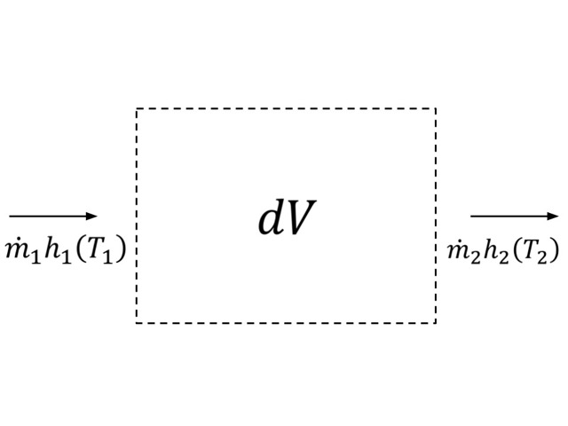

Now, if we assume adiabatic, we know that $h(T_1) = h(T_2)$, so any temperature $T_2$ that we get as a result must allow the final enthalpy to be the same as the initial enthalpy (if you're wondering why we use enthalpy and not internal energy, I recommend reading the following pdfs: https://seitzman.gatech.edu/classes/ae6765/AuxFunctions.pdf and https://www.aapt.org/docdirectory/meetingpresentations/sm14/mungan-poster.pdf). Through measurement, we are only capable of ever finding a change enthalpy. So then how do we define an absolute enthalpy at $T_1$ and $T_2$? We do so by referring to the *enthalpies of formation*, which are standard enthalpies representing the amount of chemical energy needed to break or form the set of bonds needed to form a molecule. These values of $\Delta \bar{h}_f$ are tabulated in the JANNAF or NIST tables. Certain molecules, called *elements* (not to be confused by periodic table elements) are defined to have $\Delta \bar{h}_f = 0$ at all temperatures. For the JANNAF standard, the elements conveniently happen to be very common molecules like $O_2$, $H_2$, and $C(s)$ (graphite).

Now, we can write the energy conservation in terms of the formation enthalpies:

$\frac{\sum{\chi_{i1}\bar{h}_{i1}(T_1)}}{MW_1} = \frac{\sum{\chi_{i2}\bar{h}_{i2}(T_2)}}{MW_2}$

Here, $\bar{h}_i$ values represent the partial molar enthalpies for each species on the reactant and product side. $MW$ is the molecular weight of either the reactant or product mixture. $\bar{h}$ can be represented as:

$\bar{h}_i(T) = (\bar{h}(T) - \bar{h}(T_{ref})) + \Delta \bar{h}_f(T_{ref})$

The first term in this expression is tabulated as a single value known as the *sensible enthalpy*. This is the enthalpy that's actually calculated with $c_p$ and what's easiest to measure. For ideal gases (ideal gas is a good assumption for our case because of the extremely high temperatures and the relatively low molecular weights of the reaction products), these values of enthalpy should not change with pressure. Of course, that's not entirely accurate, but not a terrible assumption. But in our case, the reactants, $CH_4$ and LOX, actually start off as liquids! Therefore, the starting enthalpies will vary with pressure more than after the combustion.

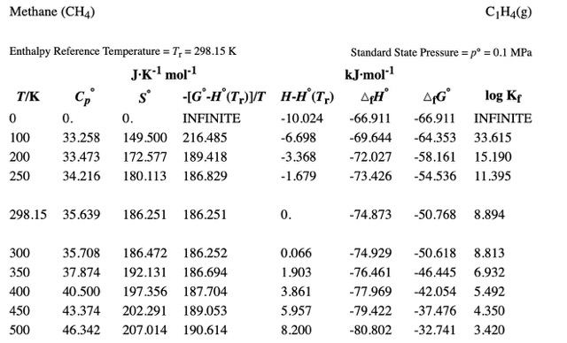

#### Formation Reactions, $K_p$, and Gibbs Functions

So now that we have a way to figure out what temperatures are within our practical range, but how do we refine our chemical composition with minor species? For one, we can continue writing more minor species.

$1.11CH_4 + 2O_2 \rightarrow n_{CO_2}CO_2 + n_{H_2O}H_2O + n_{CO}CO + n_{H_2}H_2 + n_{OH}OH + n_{O_2}O_2$

We only added two more species, but the atom balances are already insufficient to describe the entire system. In fact, we would only get three linear atom balance equations, and we need five equations total.

One thing that would simplify our life a litte is if there was table somewhere that told us the exact composition of the reaction we wrote at every temperature imaginable. Obviously that table doesn't exist: the reaction itself is way too specific. But what if there was a reaction that did have tabulated values? Before, we discussed how the major species themselves decompose to create the minor species. This true the other way around too: the minor species combine to form major species. So, we can write a separate equilibrium reaction to characterize this process. For example:

$H_2 + \frac{1}{2}O_2 \leftrightharpoons H_2O$

This type of reaction is called a *formation reaction*. It represents the process needed to form a single mole of a certain substance from the JANNAF elements. This one is particularly useful because all of the species in the formation reaction are present in the product mixture. But what does this have to do with temperature? It turns out the that ratio of the partial pressures of the species in the formation reaction are only dependent on temperature (for ideal gases). So, that means if we know the temperature, we can figure out the relative amount of each species in the formation.

$\frac{p_{H2O}}{p_{H_2}p{O_2}^{\frac{1}{2}}} = p^{-\frac{1}{2}}\frac{\chi_{H2O}}{\chi_{H_2}\chi_{O_2}^{\frac{1}{2}}} = constant$

The constant here is only a function of temperature, even though pressure is in the equation. This means that the values of this constant can be tabulated with $T$. This constant is called the *equilibrium constant*, $K_p$. So, if we know $K_p$ for a given temperature, we can use the $K_p$ formula for this formation reaction as a fourth equation. For the fifith equation, we can use the water-gas shift reaction:

$H_2O + CO \leftrightharpoons H_2 + CO_2$

$K_p(T) = \frac{p_{H_2}p_{CO_2}}{p_{H_2O}p_{CO}} = \frac{\chi_{H_2}\chi_{CO_2}}{\chi_{H_2O}\chi_{CO}}$

Keep in mind that $K_p$ equations are really only usefull when all of the species in the "helper" reaction are involed in the overall reaction. So now, we have five equations, which is all that we needed. We should be done right?

Not exactly.

Pretty much no equilibrium solver uses $K_p$ equations, and there's a good reason why. In fact, $K_p$ equations are pretty much only good if we're trying to solve the nonlinear equations by hand. But to understand why they may not be so good for computer use, we will have to explore how $K_p$ is derived for a given temperature.

By definition, $K_p = e^{-\frac{\Delta G°}{\bar{R}T}}$. $\Delta G°$ is known as the Gibbs function for a given reaction: it's a value that's minimized when a system has reached equilibrium at constant temperature and pressure. Keep in mind, $T$ and $p$ do not necessarily need to be constant during process. It's kind of like saying, "For a given $T$ and $p$, what's the minimum Gibbs free energy?" Like enthalpy or energy, $G°$ is determined as a function of temperature and pressure, so it can also be tabulated. Now imagine a final temperature and pressure at which the $\Delta G°$ for a reaction is a very large number. Now, when you calculate $e^{-\frac{\Delta G°}{\bar{R}T}}$, $K_p$ will be very close to zero, and to the computer, $K_p$ is effectively indistinguishable from 0, so the solution would diverge.

To get around this, computational methods choose to avoid using $K_p$ and instead just minimize $G(T, p)$ directly. This has to be done through iteration, but it usually only takes 2-3 iterations to solve accurately. This way, we can just jump straight to using a lot of minor species instead of just starting with the major species and working our way down. The equations used in Gibbs minimization are thoroughly described in the NASA CEA reference documentation, *Computer Program for Calculation Complex Chemical Equilibrium Compositions and Applications* (https://ntrs.nasa.gov/citations/19950013764).

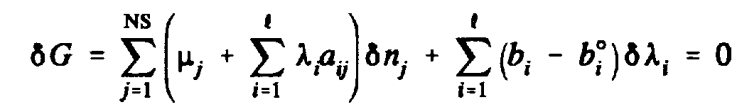

Luckily for us, these methods have been implemented many times. Let's use Cantera's built-in equilibrium solver to figure out our adiabtic flame temperature.

```python
T_O2 = 90 # K
T_CH4 = 110 # K
P = 5100 * 6894.76 # psia --> Pa

reactants = ct.ThermoPhase('gri30.yaml')
O2 = ct.Quantity(reactants, constant='HP')
O2.TPX = T_O2, P, 'O2:1'
O2.moles = 2
CH4 = ct.Quantity(reactants, constant='HP')
CH4.TPX = T_CH4, P, 'CH4:1'
CH4.moles = 1.11
products = O2 + CH4
# Find equilibrium composition with
# known h and p at the end of the process
products.equilibrate('HP', solver='gibbs')
print(products.report())
```

```
  gri30:

       temperature   3833.6 K
          pressure   3.5163e+07 Pa
           density   24.829 kg/m^3
  mean mol. weight   22.507 kg/kmol
   phase of matter   gas

                          1 kg             1 kmol
                     ---------------   ---------------
          enthalpy       -1.2483e+06       -2.8094e+07  J
   internal energy       -2.6645e+06       -5.9969e+07  J
           entropy             11468         2.581e+05  J/K
    Gibbs function       -4.5211e+07       -1.0176e+09  J
 heat capacity c_p            2314.1             52083  J/K
 heat capacity c_v            1944.7             43769  J/K

                      mass frac. Y      mole frac. X     chem. pot. / RT
                     ---------------   ---------------   ---------------
                H2         0.0055762          0.062253           -18.672
                 H        0.00070729          0.015793           -9.3361
                 O         0.0071317          0.010033           -14.452
                O2          0.043938          0.030905           -28.904
                OH          0.052642          0.069666           -23.788
               H2O           0.40466           0.50555           -33.124
               HO2        0.00047206         0.0003219            -38.24
              H2O2        0.00011721        7.7559e-05           -47.576
                 C        7.8716e-10         1.475e-09            -15.11
                CH         6.104e-10        1.0552e-09           -24.446
               CH2        1.1503e-09        1.8457e-09           -33.782
            CH2(S)        1.6098e-10        2.5831e-10           -33.782
               CH3        2.4208e-09        3.6238e-09           -43.118
               CH4        8.1745e-10        1.1468e-09           -52.455
                CO           0.19675           0.15809           -29.562
               CO2           0.28797           0.14727           -44.014
               HCO        4.3932e-05        3.4074e-05           -38.898
              CH2O        1.9495e-06        1.4613e-06           -48.234
             CH2OH        4.2156e-09        3.0573e-09            -57.57
              CH3O        1.4522e-10        1.0532e-10            -57.57
             CH3OH        3.9368e-10        2.7653e-10           -66.906
               C2H        1.3161e-12        1.1835e-12           -39.556
              C2H2        1.2618e-11        1.0907e-11           -48.892
              C2H3        3.1853e-14        2.6507e-14           -58.228
              HCCO        1.9593e-10        1.0748e-10           -54.008
             CH2CO        1.3435e-10        7.1931e-11           -63.344
             HCCOH        2.8465e-12         1.524e-12           -63.344
            CH2CHO        2.1226e-13        1.1098e-13            -72.68
            CH3CHO        4.6142e-14        2.3574e-14           -82.016
     [  +24 minor]         1.018e-14        8.1656e-15
```

We can see that, with Gibbs minimization, Cantera can calculate more than 50 species in the product mixture at once on top of calculating the adiabatic flame temperature. Of course, Gibbs isn't the only equilibrium technique. There's Helmholtz minimization or the VCS method, but they all follow the same basic idea: maximize the entropy of the mixture. This is really what Gibbs is doing in the background, it's just that it's easier to use Gibbs when all we can measure is $T$ and $p$.

As for assuming constant pressure during the equilibrium calculation, we can do that because we are calculating the composition at a single axial station in the engine, so the control volume is infinitesimally small. This means the pressure throughout the control volume is effectively constant since the combustion process is a *deflagration*: a flame with a subsonic flame speed.

# Adiabatic Flame Temperature

Adiabatic flame temperature ($T_{ad}$) is the temperature that the chamber gases would reach if there was no loss of heat into the surroundings. Since the job of a nozzle is convert chemical energy into kinetic energy, $T_{ad}$ is a good indicator of how much of the energy is actually being extracted from our propellants before the gases are accelerated. In combustion theory, instead of mixture ratio, $T_{ad}$ is usually given as a function of a similar quanitity: equivalence ratio. This is simply the given mixture ratio over the stoichiometric mixture ratio (in this case, the mixture ratio is fuel-to-oxidizer. For rocketry, we usually do oxidizer-to-fuel).

### Equivalence Ratio

The following plot gives $T_{ad}$ as a function of $\phi$, the equivalence ratio.

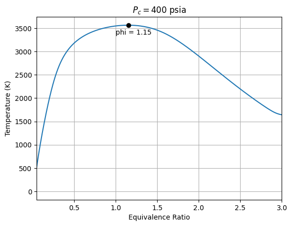

```python
Pc = 400 # psia
Pe = 8 # psia
phi = np.linspace(0, 5, 1000)


Tad = np.zeros((len(phi)))
for j in range(len(phi)):
    #print(rocket.getMRforER(phi[j]))
    MR = rocket.getMRforER(phi[j])
    Tad[j] = rocket.get_Tcomb(Pc, MR)
Tad_max_index = Tad.argmax()

plt.figure
plt.scatter(phi[Tad_max_index], Tad[Tad_max_index], c = 'k', zorder = 3)
plt.annotate(f"phi = {(phi[Tad_max_index]):.2f}",
             (phi[Tad_max_index], Tad[Tad_max_index]),
             (phi[Tad_max_index] - 0.15, Tad[Tad_max_index]-200))
plt.plot(phi, Tad)
plt.xlim([0.05, 3])
plt.ylabel('Temperature (K)')
plt.xlabel('Equivalence Ratio')
plt.grid(True)
plt.title(fr"$P_c = ${Pc} psia");
```

As you can see, the temperature is highest near $\phi$ = 1 but slightly greater than 1. This is primarily because going slightly fuel rich makes up for energy that would be lost due to dissociation of the major species at those high temperatures. At high temperatures, species like $CO_2$ and $H_2O$ will start to form $CO$ or $OH$, which require high enthalpies of formation. Some of the energy that could have gone into generating thermal energy (translations, rotations, and vibrations of molecules) goes into breaking bonds (chemical energy). The occurs the least when the mixture is slightly richer for many hydrocarbon fuels (the relation may not necessarily hold if the hydrocarbons are heavier than the oxidizer, for example). You can kind of think of this by using the fact that $dh = C_p dT$, so maximizing the thermal energy requires a smaller molecular weight since that leads to higher $C_p$.

It would then seem plasuible to simply design the engine to operate close to stoich so that we get the highest energy release. However, the highest chamber temperature does not necessarily correspond to the highest exhaust kinetic energy (and therefore exhaust velocity, $V_e$), which is what *actually* needs to be maximized. Moreover, a high chamber temperature would make the TCA (thrust chamber assembly) hotter through convective heating, which leads to TCA yielding under thrust loads. To avoid this, we can run fuel rich or lean: whichever one gives the best efficiency.

To make this chart a bit more friendly for our discussion, $T_{ad}$ can plotted with respect to $MR$ (oxidizer-to-fuel)

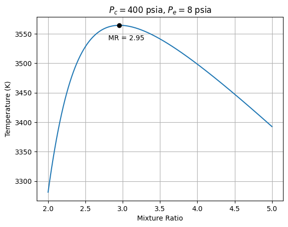

```python
MR = np.linspace(2, 5, 400)
Tad = np.zeros((len(MR)))
for i in range(len(MR)):
    Tad[i] = rocket.get_Tcomb(Pc, MR[i])
Tad_max_index = Tad.argmax()
plt.figure
plt.scatter(MR[Tad_max_index], Tad[Tad_max_index], c = 'k', zorder = 3)
plt.annotate(f"MR = {(MR[Tad_max_index]):.2f}",
             (MR[Tad_max_index], Tad[Tad_max_index]),
             (MR[Tad_max_index] - 0.15, Tad[Tad_max_index]-25))
plt.plot(MR, Tad)
plt.ylabel('Temperature (K)')
plt.xlabel('Mixture Ratio')
plt.grid(True)
plt.title(fr"$P_c = ${Pc} psia, $P_e = ${Pe} psia");
```

### $T_c$ vs. $P_c$

Before moving on, I think it would also be good to observe the effect of altering chamber pressure on chamber temperature.

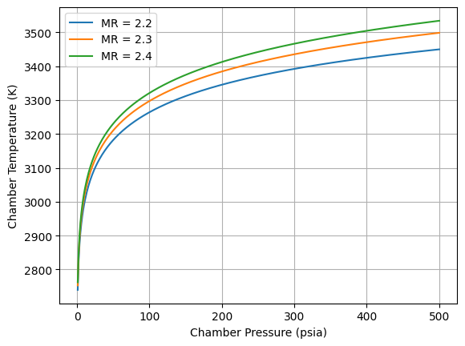

```python
Pc = np.linspace(1, 500, 400) # psia
MR = np.array([2.2, 2.3, 2.4])

Tc = np.zeros((len(MR), len(Pc)))
for i in range(len(MR)):
    for j in range (len(Pc)):
        Tc[i, j] = rocket.get_Tcomb(Pc[j], MR[i])
plt.Figure
for i in range(len(MR)):
    plt.plot(Pc, Tc[i, :], label = f"MR = {MR[i]}")
plt.xlabel('Chamber Pressure (psia)')
plt.ylabel('Chamber Temperature (K)')
plt.grid(True)
plt.legend();
```

In the chamber pressure region that is most likely to concern YJSP (200 - 500 psia), it's clear that temperature seems to increase monotonically with pressure and that, as shown before, increasing $MR$ appears to also increase $T_c$. While the it's essential to know the exact magnitudes of these changes, having a general intution for how tweaking certain overall parameters can affect your engien conditions is very helpful for communicating with other engineers.

### $MR_{T_{max}}$ vs $P_c$

To better understand how the adiabatic flame temperature is affected by the chamber pressure, let's plot the relationship between the $MR$ that produces the highect $T_c$ and $P_c$

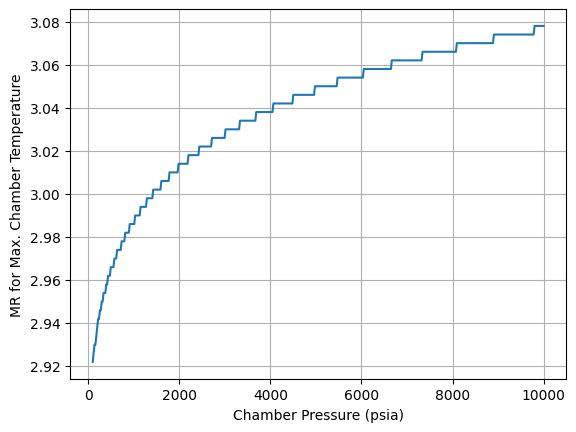

```python
Pc = np.linspace(100, 10000, 500) # psia
MR = np.linspace(2, 4, 500) # arbitrary

MR_max_T = np.zeros(len(Pc))
for i, p in enumerate(Pc):
    Tc = np.zeros(len(MR))
    for j, mc in enumerate(MR):
        Tc[j] = rocket.get_Tcomb(p, mc)
    ind = Tc.argmax()
    MR_max_T[i] = MR[ind]

plt.Figure
plt.plot(Pc, MR_max_T)
plt.grid(True)
plt.xlabel("Chamber Pressure (psia)")
plt.ylabel("MR for Max. Chamber Temperature");
```

We can see pretty clearly that the chamber pressure increasing corresponds to an increase in the $MR$ required to induce the maximum chamber temperature. Each of the points on this curve theoretically corresponds to $\phi = 1$, but how? Shouldn't $\phi$ to get the maximum temperature stay the same? Not necessarily, because when the pressure that the combustion occurs at changes, so to does the equilibrium composition. It's not a simple as balancing a simple chemical reaction like for photosythesis. Instead, for combustion, many minor and major products all form is varying in concentrations depending on the pressure. As the pressure increases, certain molecules that were low in concentration before could now become a more relevant.

Therefore, it's somewhat of a weird question to ask, "What is stoich for these propellants?" without specifying the chamber pressure.

You may have also noticed that this curve looks a little **chopped** if you didn't index enough point for $P_c$ and $MR$. However, using a lot of points can take forever. A technique to get around this is discussed in the later sections.

# Specific Heat and Exhaust Molecular Weights

With a rocket engine, your goal is to take all of the stored chemical energy in your propellants and convert it into as much kinetic energy as you can. This means that for a given nozzle, there is a given amount of "exhaust kinetic energy" (the kinetic energy of the molecules exiting the nozzle).This fact can be shown with steady-flow conversation of energy (assume the chamber has negligible fluid velocity):

$h_{c} = h_{e} + \frac{1}{2}V_e^2$

Both $h_c$ and $h_e$ are functions of their respective temperatures, $T_c$ and $T_e$, respectively. Since $T_c$ is set by the chamber pressure and $T_e$ and is set by the shape of the nozzle, $V_e$ (and therefore the exhaust kinetic energy) is also fixed. The goal, then, is to maximize $h_c$ and minimze $h_e$ so that $V_e$ is as large as possible. Why? Using conservation of momentum gives:

$\tau = \dot{m}V_e + (P_e - P_{amb})A_e$

This means that increasing mass flow rate AND $V_e$ are essential to getting the most thrust that we can out of our engine. Usually, since our $P_c$ and throat area are set, our mass flow rate will be fixed due to flow choking. Therefore, we're most interested in maximizing our exhaust velocity, which, assuming we are perfectly expanded, is the thrust per unit mass flow rate. So in reality, getting most thrust for a given mass flow (which is a set function of a our nozzle shape and pressure) is really about minimizing $h_e$ because with a fixed $P_c$ and $T_c$, $h_c$ is also fixed.

Rearranging the energy equation and assuming that the gas is thermally perfect (which is a valid assumption due to the extremely high temperatures) gives:

$V_e = \sqrt{\int_{T_e}^{T_c}c_p dT}$

For the sake of this modeling, we will assume that the flow is calorically perfect (which isn't necessarily a bad assumption when doing preliminary sizing):

$V_e = \sqrt{c_p(T_c - T_e)}$

We can see that maximizing $V_e$ requires increasing $c_p$, the specific heat at constant pressure. This makes sense because having a higher specific heat for given $h_c$ means that you're effectively dropping $h_e$ more for the same $\Delta T = T_c - T_e$. Therefore, the question now becomes *how do we maximize $c_P$*?

The following chart gives some insight into how we can do that:

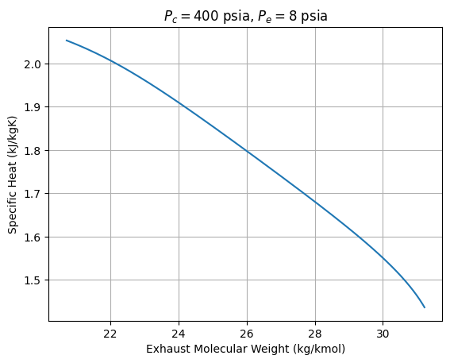

```python
Pc = 400 # psia
Pe = 8 # psia
MR = np.linspace(2, 10, 400)

Cp = np.zeros((len(MR)))
MW = np.zeros((len(MR)))
for i in range(len(MR)):
    epsilon = rocket.get_eps_at_PcOvPe(Pc, MR[i], Pc/Pe, 1, 0)
    # don't worry about these last two parameters,
    # they will be explained later on
    cp_avg = np.average(rocket.get_HeatCapacities(Pc, MR[i],
                                                  epsilon, 1, 0))
    mc, _ = rocket.get_exit_MolWt_gamma(Pc, MR[i], epsilon, 1, 0)
    Cp[i] = cp_avg
    MW[i] = mc

plt.figure
plt.plot(MW, Cp)
plt.xlabel('Exhaust Molecular Weight (kg/kmol)')
plt.ylabel('Specific Heat (kJ/kgK)')
plt.grid(True)
plt.title(fr"$P_c = ${Pc} psia, $P_e = ${Pe} psia");
```

Let's also see how $MW$ changes with $MR$

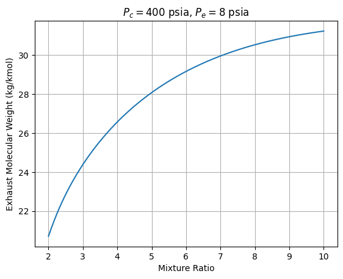

```python
plt.figure
plt.plot(MR, MW)
plt.xlabel('Mixture Ratio')
plt.ylabel('Exhaust Molecular Weight (kg/kmol)')
plt.grid(True)
plt.title(fr"$P_c = ${Pc} psia, $P_e = ${Pe} psia");
```

As we can see, decreasing the molecular weight of the gases can increase the specific heat. Therefore, when trying to increase the exhaust velocity, it is best to aim for a lower molcular weight. Logically, this makes sense: for a given amount of kinetic energy, the smaller molecules will have higher velocity. Going back to the energy equation, it can be rewritten as:

$\frac{T_c}{T_e} = 1 + \frac{V_e^2}{2c_pT_e}$

This is more commonly recogrnized in the form:

$\frac{T_c}{T_e} = 1 + \frac{\gamma - 1}{2}M^2$

While this is used frequently with isentropic relations, this equation in particular is not necessarily an isentropic relation but rather an energy conservation equation for a steady, adiabatic system. With $T_c$ and $T_e$ fixed, it is clear that maximizing $V_e$ (or $M$) is the same as maximizing $c_p$ or minimizing $\gamma$.

This makes sense since for an ideal gas:

$\gamma = \frac{c_p}{c_v} = \frac{c_p}{c_p - R}$

Since $R < c_p$ is always true, the larger that $c_p$ gets, the smaller and closer to 1 that the $\gamma$ gets.

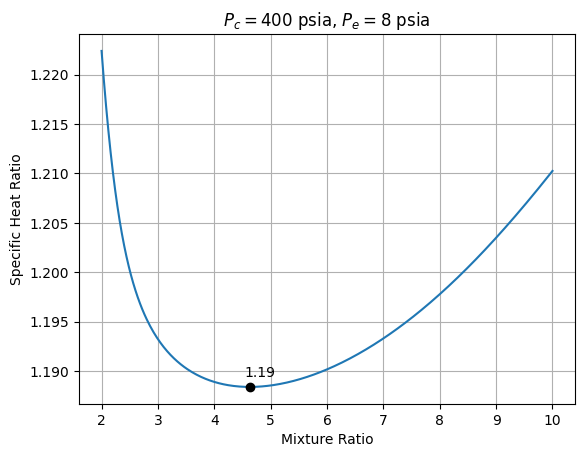

```python
gamma = np.zeros((len(MR)))
for i in range(len(MR)):
    epsilon = rocket.get_eps_at_PcOvPe(Pc, MR[i], Pc/Pe, 1, 0)
    _, gc = rocket.get_Chamber_MolWt_gamma(Pc, MR[i], epsilon)
    _, gt = rocket.get_Throat_MolWt_gamma(Pc, MR[i], epsilon, 1)
    _, ge = rocket.get_exit_MolWt_gamma(Pc, MR[i], epsilon, 1, 0)
    gamma[i] = np.average((gc, gt, ge))

plt.figure
plt.plot(MR, gamma)
plt.ylabel('Specific Heat Ratio')
plt.xlabel('Mixture Ratio')
plt.grid(True)

gamma_min_ind = gamma.argmin()
plt.scatter(MR[gamma_min_ind], gamma[gamma_min_ind], c = 'k', zorder = 3)
plt.annotate(f"{(gamma[gamma_min_ind]):.2f}",
             (MR[gamma_min_ind], gamma[gamma_min_ind]),
             (MR[gamma_min_ind]-0.1, gamma[gamma_min_ind]+0.001))
plt.title(fr"$P_c = ${Pc} psia, $P_e = ${Pe} psia");
```

There is clearly a minimum gamma point, but whether it's in a practical MR is yet to be shown. Notice that the gamma values tend to hover around ~1.2. In fact, $\gamma = 1.2$ is a decent estimate when doing preliminary engine sizing. The big takeaway from this plot is that we can decrease $\gamma$ by increasing mixture ratio up until a certain point.

So far, we have tried to optimize our mixture ratio by increasing our $T_{ad}$ and decreasing our $\gamma$ (which was equivalent to minimizng our molecular weight) as much as possible. Together these parameters are great for figuring out how maximize orur $V_e$. Wouldn't it be great to have a single value that lets us analyze both at the same time?

# $C^{*}$ and $C^{*}_{eff}$

The characteristic velocity, $C^{*}$, is how we quantify how much chemical energy is available to be converted into kinetic energy at the nozzle exit. In other words, it's directly proportional to how much useful energy exists in the engine at any given time. This is why NASA CEA's $C^*$ values are the same at the throat and exit. It accounts for all of the effects of maximizing adiabatic flame temperature and specific heat. The higher your $C^{*}$, the more energy your engine is able to get out of your propellants. Let's plot $C^{*}$ as function of mixture ratio.

$C^{*} = \frac{P_cA_t}{\dot{m}}$

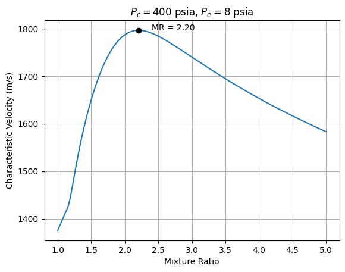

```python
Pc = 400 # psia
Pe = 8 # psia
MR = np.linspace(1, 5, 400)

cstar = np.zeros((len(MR)))
cstar_test = np.zeros((len(MR)))
for i in range(len(MR)):
    eps = rocket.get_eps_at_PcOvPe(Pc, MR[i], Pc/Pe, 1, 0)
    cstar[i] = rocket.get_Cstar(Pc, MR[i])
    _, Tt, _ = rocket.get_Temperatures(Pc, MR[i], eps, 1, 0)
    mw, g = rocket.get_Throat_MolWt_gamma(Pc, MR[i], eps, 1)
    cstar_test[i] = ((1 + (g-1)/2)**(g/(g-1)))*np.sqrt(8314*Tt/(mw*g))

plt.Figure
plt.plot(MR, cstar)
plt.grid(True)
plt.xlabel("Mixture Ratio")
plt.ylabel("Characteristic Velocity (m/s)")

max_cstar_ind = cstar.argmax()
plt.scatter(MR[max_cstar_ind], cstar[max_cstar_ind], c = 'k', zorder = 3)
plt.annotate(f"MR = {(MR[max_cstar_ind]):.2f}",
             (MR[max_cstar_ind], cstar[max_cstar_ind]),
             (MR[max_cstar_ind] +0.2, cstar[max_cstar_ind]))
plt.title(fr"$P_c = ${Pc} psia, $P_e = ${Pe} psia");
```

**BE AWARE**: Rocket CEA tends to calculate $C^*$ to be around 2-3% higher than what NASA CEA calculates. NASA CEA is more accurate to what the value should actually be, which I found out by manually calculating $C^*$. This is important to note when we are trying to gather efficiency data from testing. Here's a quick plot showing the difference

```
Max Percent difference: 2.66%
```

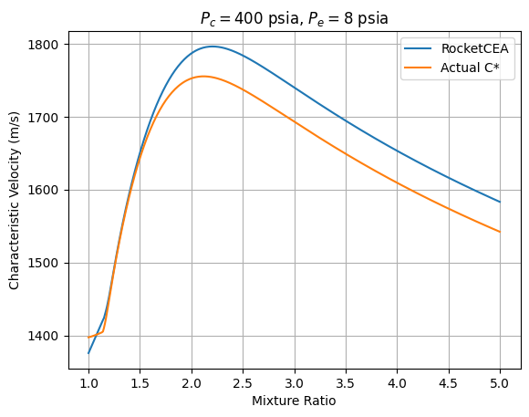

```python
plt.Figure
plt.plot(MR, cstar, label = "RocketCEA")
plt.grid(True)
plt.xlabel("Mixture Ratio")
plt.ylabel("Characteristic Velocity (m/s)")

plt.plot(MR, cstar_test, label= "Actual C*")
plt.legend()

print(f"Max Percent difference: {((cstar[-1]*100/cstar_test[-1]) - 100):.2f}%")
plt.title(fr"$P_c = ${Pc} psia, $P_e = ${Pe} psia");
```

Let's also plot $C^*$ as a function of $P_c$.

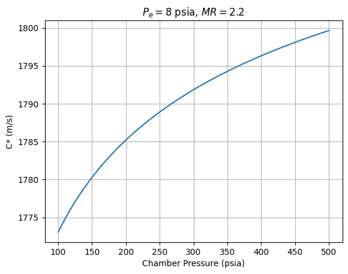

```python
Pc = np.linspace(100, 500, 400) #psia
Pe = 8 # psia
MR = 2.2

cstar = np.zeros(len(Pc))
for i, p in enumerate(Pc):
    cstar[i] = rocket.get_Cstar(p, MR)

plt.figure
plt.plot(Pc, cstar)
plt.grid(True)
plt.xlabel("Chamber Pressure (psia)")
plt.ylabel("C* (m/s)")
plt.title(fr"$P_e = ${Pe} psia, $MR = ${MR}");
```

$C^*$ goes up with chamber pressure! This ties in to how well the energy is being released from our propellants: the higher the $P_c$, the higher the $T_c$, so there will be more energy to use to generate thrust, making the thrust higher for a given mass flow rate.

$C^*$ gives a bit more of a complete picture because now the curves for $T_{ad}$ and $\gamma$ have essentially combined to give an $MR$ that encompases all of the previously discussed effects. In fact, if we put together all of our isentropic relations and substitute into our earlier $C^{*}$ equation, we get:

$C^{*} = \sqrt{\frac{1}{\gamma}\left(\frac{\gamma + 1}{2}\right)^{\frac{\gamma+1}{\gamma -1}}\frac{\bar{R}}{MW}T_c}$

We see in this equation all of the design choices that were previously mentioned: to maximize $C^*$, it's best to minimize $\gamma$, minimze $MW$, and maximize $T_c$.

Say that you've now designed the engine to operate at an $MR$ that gives you the highest possible $C^{*}$. How do we know we're actually hitting that $C^{*}$? In reality, we can never actually achieve the design $C^{*}$, but we can get pretty close. How close we get to this value is called $C^{*}$ *efficiency* : it's a direct result of how well our propellants actually combine to release energy. $C^{*}_{eff}$ is function of a few variables but mainly:

1. **injector atomization and mixing**: the better your injector can bring the propellants together, the better they'll react. This usually plays the biggest role in affecting $C^{*}_{eff}$, which is why $C^{*}_{eff}$ is usually seen as a direct measure of injector performance.
2. **$L^{*}$, characteristic length**: propellants need time to react, and they get that time through the space in the chamber they have before accelerating through the nozzle. Bulkier propellants need more time and space to react. Check out Figure 4-7 in H&H (*Design of Liquid Propellant Rocket Engines* by Huzel and Huang) for more info on how $L^{*}$ and $C^{*}_{eff}$ are related. These kinds of relations can be determined through kinetics simulations but primarily through testing.
3. **Vaporization Loss**: All liquid propellants need energy to turn into gases. This is easier when they're atomized, but it takes some energy from the combustion process nonetheless.
4. **Film Cooling Loss**: fuel vapor jets can be used to create a higher equivalence ratio along the chamber walls, cooling them. This however, reduces the overall $T_c$, altering the exhaust velocity.
5. **Rayleigh Line Losses**: These are losses due to heat being absorbed through the chamber walls, which is effectively a straight cooling duct. This will take away some the energy from the low, reducing the exhaust velocity.

$C^{*}_{eff}$ is defined as $\frac{C^{*}_{actual}}{C^{*}_{ideal}}$, so the plot above actually reads the *ideal* $C^{*}$. When testing, we have a theoretical $C^{*}$ that we would like to hit. We compare that value to what we actually got to get a measure of how good our combustion is. Good injectors and engines can reach $C^{*}_{eff}$'s of 95% or even above that. A key takeway from this section is that because all of these variables were being used to optimize $V_e$, $C^{*}_{eff}$ is a direct measure of how close we are to the desired $V_e$.

Returning back to our original energy conservation equation, $h_{c} = h_{e} + \frac{1}{2}V_e^2$, we determined that the way to maximize our kinetic energy output was to maximize the difference $h_{c} - h_{e}$. Before, because we held $T_c$ (which is essentially $T_{ad}$ for our purposes) and $P_c$ constant, $h_c$ was also fixed. To clarify, *this is not because $P_c$ and $T_c$ are indpendent variables* that we can claim that $h_c$ is fixed but rather because $P_c$ and the composition, $MR$, are fixed for an engine. In fact, we literally saw $T_{ad}$ changing with mixture ratio and chamber pressure earlier. This is why $MR$ and $P_c$ are chosen as independent chamber parameters and not $T_{ad}$. Does this make the analysis done in the *Specific Heat and Exhaust Molecular Weight* section invalid? Not at all. It simply means that while we chose to observe the effects of altering mixture ratio on a single variable, in reality, many variables are affected by messing around with our key parameters. This is why $C^*$ is so helpful, it takes into the effects of changing $P_c$ and $MR$ on $T_c$ (and therefore $h_c$) and $c_p$.

Another parameter that we assumed to be fixed during this analysis was the nozzle itself, which, for a given $T_c$, assuming isentropic flow, also fixes your $T_e$. But maybe we can also strike a balance between our nozzle shape and the $MR$ to alter $T_e$ in such a way that gets us the highest $V_e$?

# $C_{\tau}$, Thrust Coefficient

From $h_{c} = h_{e} + \frac{1}{2}V_e^2$, we derived $V_e = \sqrt{c_p(T_c - T_e)}$, and previously, we focused primarily on adjusting $c_p$ and $T_c$, using $C^*$. However, if we now allow the nozzle shape to change as well, it's possible to also alter $T_e$ for a given $T_c$ and $MR$. Let's break apart $h_e$ using the definition of enthalpy:

$h_e(T_e) = u_e(T_e) + \frac{P_e}{\rho_e} = u_e(T_e) + RT_e$

Therefore, minimizing $h_e$ is all about making $u_e$ and $T_e$ as low possible. Since $u_e$ will decrease with temperature, it's really all about $T_e$. This the same as what $V_e = \sqrt{c_p(T_c - T_e)}$ is telling us. So how can this be done? Let's write $V_e = \sqrt{c_p(T_c - T_e)}$ in terms of Mach number and $\gamma$ instead:

$M_e = \sqrt{\left(\frac{T_c}{T_e} - 1\right)\frac{2}{\gamma - 1}}$

We will then substitute into the equation relating nozzle cross-sectional area to $M$: $\frac{A}{A_t} = \frac{1}{M}\left(\frac{1 + \frac{\gamma - 1}{2}M^2}{\frac{\gamma + 1}{2}}\right)^{\frac{\gamma + 1}{2(\gamma-1)}}$

$\frac{A_e}{A_t} = \frac{1}{\sqrt{\left(\frac{T_c}{T_e} - 1\right)\frac{2}{\gamma - 1}}}\left(\frac{T_c/T_e}{\frac{\gamma + 1}{2}}\right)^{\frac{\gamma + 1}{2(\gamma-1)}}$

The quantity $\frac{A_e}{A_t}$ is also known as $\epsilon$, the expansion ratio. For a fixed mass flow rate, $A_t$ will be fixed as well, so the $T_e$ can be plotted as a function of $\epsilon$

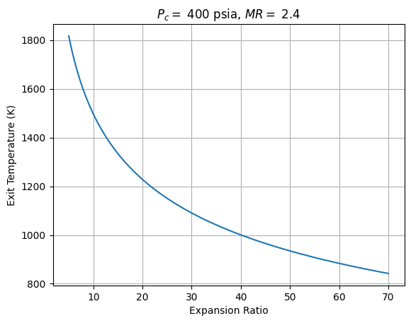

```python
Pc = 400 # psia
MR = 2.4
epsilon = np.linspace(5, 70, 400)

Te = np.zeros((len(epsilon)))
Pe = np.zeros((len(epsilon)))
for i in range(len(epsilon)):
    _, _, Te[i] = rocket.get_Temperatures(Pc, MR, epsilon[i], 1, 0)
    Pe[i] = Pc / (rocket.get_PcOvPe(Pc, MR, epsilon[i], 1, 0))

plt.Figure
plt.plot(epsilon, Te)
plt.grid(True)
plt.xlabel('Expansion Ratio')
plt.ylabel('Exit Temperature (K)')
plt.title(f"$P_c =$ {Pc} psia, $MR = $ {MR}");
```

Let's do the same for exit pressure.

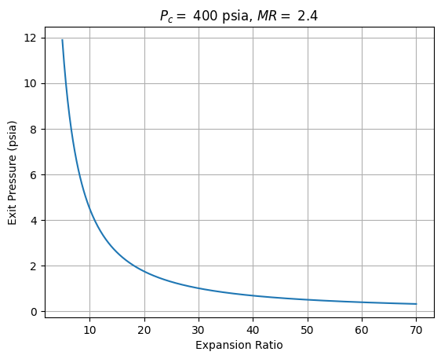

```python
plt.Figure
plt.plot(epsilon, Pe)
plt.grid(True)
plt.xlabel('Expansion Ratio')
plt.ylabel('Exit Pressure (psia)')
plt.title(f"$P_c =$ {Pc} psia, $MR = $ {MR}");
```

Not only does the temperature get lower with expansion ratio, but so does the pressure. This makes sense from a few standpoints. With $\frac{T_c}{T_e} = \left(\frac{P_c}{P_e}\right)^{\frac{\gamma}{\gamma - 1}}$, we can see that for the fixed chamber condtions, if $T_e$ goes lower, $P_e$ goes lower. Addtionally, just from intuition, if we want a higher flow speed, we need a greater $\Delta p$, hence $P_e$ must be lower.

Therefore, since an expanded nozzle decreases $T_e$ and $P_e$, it's clear that expanding the nozzle (increasing the exit area) plays a substantial role in how high the exhaust velocity gets. In fact, we could have simply seen that fact in this equation, $\frac{A}{A_t} = \frac{1}{M}\left(\frac{1 + \frac{\gamma - 1}{2}M^2}{\frac{\gamma + 1}{2}}\right)^{\frac{\gamma + 1}{2(\gamma-1)}}$, but I think it's helpful to see how energy conservation plays a role in optimizing our nozzle.

So as we increase our $\epsilon$, we get a higher $V_e$, and since our mass flow rate is fixed by $P_c$ and $MR$, by $\tau = \dot{m}V_e$ (perfect expansion case), our thrust goes up! So, in other words, by adding a nozzle, we've increased the amount of thrust that we would have gotten as opposed to just having a cylindrical engine. The thrust generated by this theoretical cylinder engine would just be the chamber pressure times some reference area. We will use the throat as our reference, so the reference thrust is $P_cA_t$. To compare this to how good our thrust actually is with the nozzle, we can do $\frac{\tau}{P_cA_t}$. This quantity has a special name: the *Thrust Coefficient*, $C_{\tau}$. If $C^*$ is a measure of how good our propellant chemistry is at generating thrust, $C_{\tau}$ is a measure of how good our nozzle is. This does not mean that it is independent of chamber pressure, however. Let's verify this

**BE CAREFUL** when using RocketCEA's *getFrozen_PambCf()* or *get_PambCf()* functions. They output a tuple of form (perfect expansion $C_{\tau}$ (what NASA CES gives), actual $C_{\tau}$, and the type of expansion).

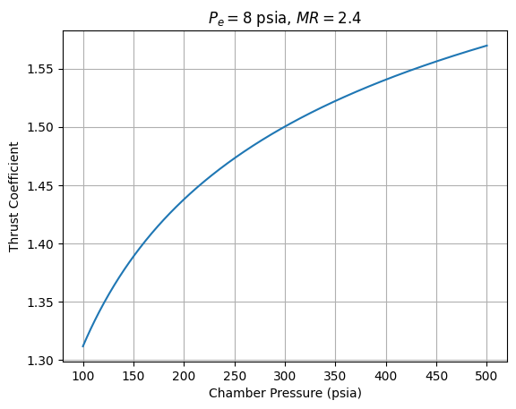

```python
Pc = np.linspace(100, 500, 400) # psia
Pe = 8 # psia
MR = 2.4

Ct = np.zeros((len(Pc)))
for i in range(len(Pc)):
    epsilon = rocket.get_eps_at_PcOvPe(Pc[i], MR, Pc[i]/Pe, 1, 0)
    _, Ct[i], _ = rocket.getFrozen_PambCf(Pe, Pc[i], MR, epsilon, 0)
plt.figure
plt.plot(Pc, Ct)
plt.xlabel("Chamber Pressure (psia)")
plt.ylabel("Thrust Coefficient")
plt.grid(True)
plt.title(f"$P_e = ${Pe} psia, $MR = ${MR}");
```

**NOTICE** that I never used thrust to calculate the thrust coefficient! This implies that $C_{\tau}$ is more a function of the nozzle and the chamber conditions rather than our desired thrust. We can see why by expanding the definition of thrust coefficient using mass conservation for the perfectly expanded case:

$C_{\tau} = \frac{\tau}{P_cA_t} = \frac{\dot{m}V_e}{P_cA_t} = \frac{\dot{m}V_e}{P_cA_t} = \frac{\rho_t V_tV_e}{P_c} = \frac{\rho_t \sqrt{\gamma R T_t}V_e}{P_c} = \frac{P_t\sqrt{\gamma R T_t}V_e}{RT_tP_c}$

Because we know all of the upstream conditions and the fact that $M_t = 1$, $C_{\tau}$ can be calculated without $\tau$. This relationship can be neatly summarized in this formula: $C_{\tau} = \sqrt{\frac{2\gamma^2}{\gamma - 1}\left(\frac{2}{\gamma + 2}\right)^{\frac{\gamma + 1}{\gamma - 1}}\left(1 - \left(\frac{P_e}{P_c}\right)^{\frac{\gamma - 1}{\gamma}}\right)}$. If the nozzle is not perfectly expanded, then the formula becomes:

$C_{\tau} = \sqrt{\frac{2\gamma^2}{\gamma - 1}\left(\frac{2}{\gamma + 2}\right)^{\frac{\gamma + 1}{\gamma - 1}}\left(1 - \left(\frac{P_e}{P_c}\right)^{\frac{\gamma - 1}{\gamma}}\right)} + \epsilon\left(\frac{P_e - P_{amb}}{P_c}\right)$

Even though $C_{\tau}$ changes with pressure, when discussing changes in pressure that are over hundreds of psia, it's safe to assume that the thrust coefficient does not change too much. For example, between 300 and 400 psia, the thrust coefficient increases by less than 0.1. Therefore, when testing, with slight errors in hitting the target chamber pressure, it is safe to say that $C_{\tau}$ remains roughly constant. When deciding on what chamber pressure to use for a given thrust, we can refer to $\tau = C_{\tau}P_cA_t$. Because we know that $C_{\tau}$ increases with $P_c$, we can safely say that a given thrust is easier to achieve with a higher pressure. We can also conclude that a higher thrust can be achieved using a lower pressure with a better nozzle. It should be noted that $C_{\tau}$ by itself is not a measure of efficiency but rather a theoretical values that represents how much more thrust we can get. Similar to characteristic velocity, whether or not we hit a $C_{\tau}$ would be determined by our manufacturing ability and validating in testing.

Let's check out how the thrust coefficient is affect by the ambient pressure

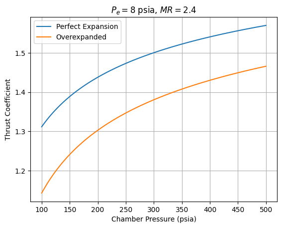

```python
Ct = np.zeros((2, len(Pc)))
for i in range(len(Pc)):
    epsilon = rocket.get_eps_at_PcOvPe(Pc[i], MR, Pc[i]/Pe, 1, 0)
    Ct[0, i], Ct[1, i], _ = rocket.getFrozen_PambCf(14.67, Pc[i], MR,
                                                    epsilon, 0)

plt.figure
plt.plot(Pc, Ct[0, :], label = 'Perfect Expansion')
plt.plot(Pc, Ct[1, :], label = "Overexpanded")
plt.xlabel("Chamber Pressure (psia)")
plt.ylabel("Thrust Coefficient")
plt.legend()
plt.grid(True)
plt.title(f"$P_e = ${Pe} psia, $MR = ${MR}");
```

This tells us that $\frac{\tau}{\dot{m}}$ goes down as the ambient pressure increases relative to the exit pressure. Therefore, if we want to get same amount of the thrust as we increase ambient pressure, we need a higher mass flow rate.

Let's see how our thrust coefficient changes with $MR$, assuming that the nozzle is perfectly expanded.

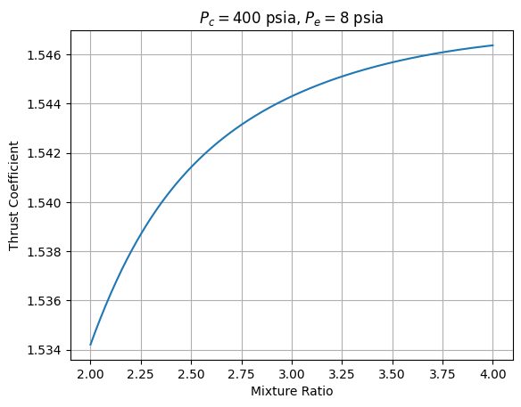

```python
Pc = 400 # psia
Pe = 8 # psia
MR = np.linspace(2, 4, 400)

Ct = np.zeros((len(MR)))
for i in range(len(MR)):
    epsilon = rocket.get_eps_at_PcOvPe(Pc, MR[i], Pc/Pe, 1, 0)
    #print(rocket.getFrozen_PambCf(Pe, Pc, MR[i], epsilon, 0))
    _, Ct[i], _ = rocket.getFrozen_PambCf(Pe, Pc, MR[i], epsilon, 0)
plt.Figure
plt.plot(MR, Ct)
plt.grid(True)
plt.xlabel("Mixture Ratio")
plt.ylabel("Thrust Coefficient")
plt.title(f"$P_c = ${Pc} psia, $P_e = ${Pe} psia");
```

While $MR$ does effect thrust coefficient, the change is slight in the region that anyone would be designing an RP-1/LOX engine. This means that while we can try to land on a compromise between nozzle shape and mixture ratio, choosing a mixture ratio that improves mixing efficiency should be the priority. That being said, it's clear from the calculation of $C_{\tau}$ that $C_{\tau}$ itself is dependent on $\gamma$, which, as we discussed, plays a huge role in determining the exhaust velocity. Therefore, both $C_{\tau}$ and $C^*$ should be taken into account when choosing an MR to get the highest possible exhaust velocity.

Before diving into how that's done, I think it would be a good idea to see how these variables play together.

# Relating $C^*$ and $C_{\tau}$ to Thrust and Mass Flow Rate

Before proceeding with this section, I highly recommend reading the document titled *Characteristic Velocity and Thrust Coefficient* in the github repository in which this guide is stored. It has essential information on how, when, and why $c^*$ and $C_{\tau}$ are used. It is very important to use these values properly, or else you may risk improperly sizing your engine or falsely interpreting your test data.

Let's say that you're sizing vehicle and engine with the following assumptions and parameters:

- $\tau = 2500$ lbf
- $P_c = 300$ psia
- $P_e = 10$ psia
- $MR = 2$
- $\epsilon_c$ = 4.3
- $L^* = 40$ inches
- $C^*_{eff} = 85\%$

To size your tanks, for a given fixed throat area, you need to know your engine's mass flow rate. How do we find this value?

```python
T = 2500 # lbf
Pc = 300 # psia
Pe = 10 # psia
MR = 2
C_star_eff = 0.85
```

Just based on $C^*_{eff}$, you may have already guessed that our propellant mixing isn't happening as well as we'd like or that some other phenomenon is taking away energy from the combustion gases. This would decrease $V_e$, so the ideal mass flow rate for $C^*_{eff} = 100\%$ isn't going to achieve the thrust we want. In fact, as $C^*_{eff}$ decereases for the same $P_c$, the amount of mass flow expelled from the engine goes up proportionally as $\dot{m}_{actual} = \frac{\dot{m}_{ideal}}{C^*_{eff}}$. So the thrust actually remains mostly unaffected (thrust is almost entirely dependent on chamber pressure and nozzle shape, not $C^*_{eff}$. Of course, changing $C^*_{eff}$ will change molecular composition slightly, so thrust will be slightly affected). The $C^*_{eff}$ could be lower either because of our injector's mixing capabilities or because our $L^*$ is too short. Let's first figure out what the ideal case would be.

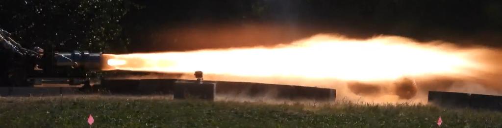

### Ideal Case ($C^*_{eff} = 100\%$)

When we're doing this kind of analysis, we should do it for the perfectly expanded case (more on why we do this in later sections). Therefore, $\tau = \dot{m}V_e$. CEA, using energy conservation, can actually determine $V_e$ for us.

```python
epsilon = rocket.get_eps_at_PcOvPe(Pc, MR, Pc/Pe, 1, 0)
_, _, ae = rocket.get_SonicVelocities(Pc, MR, epsilon, 1, 0)
# exit sonic velocity
Me = rocket.get_MachNumber(Pc, MR, epsilon, 1, 0)
# exit Mach number
Ve_ideal = ae*Me
print(f"Exhaust Velocity = {Ve_ideal:.2f} m/s")
```

```
Exhaust Velocity = 2556.47 m/s
```

Since we know thrust and $V_e$, we can find $\dot{m}$. Let's make sure to convert our thrust units to Newtons from lbf.

```python
mdot_ideal = (T * 4.44822) / Ve_ideal # lbf --> N
print(f"Ideal Mass Flow Rate = {mdot_ideal:.2f} kg/s")
```

```
Ideal Mass Flow Rate = 4.35 kg/s
```

With our mixture ratio, we can actually figure out our individual fuel and oxidizer flow rates.

```python
fuel_mdot = (1/(MR+1))*mdot_ideal # 1 part fuel for MR parts oxidizer
ox_mdot = (MR/(MR+1))*mdot_ideal
print(f"Fuel: {fuel_mdot:.2f} kg/s, Oxidizer: {ox_mdot:.2f} kg/s")
```

```
Fuel: 1.45 kg/s, Oxidizer: 2.90 kg/s
```

### $C^*_{eff} = 85\%$

Now let's check if we can achieve the desired thrust with this flow rate and 85% $C^*$ efficiency. Let's start by using the definitions of thrust, $C^*$ and $C_{\tau}$ for perfect expansion:

$\tau = \dot{m}V_e$

$C^*_{ideal} = \frac{P_cA_t}{\dot{m}}$

$C_{\tau, ideal} = \frac{\tau}{P_cA_t}$

We can rewrite $C^*_{ideal}$ in terms of efficiency as $C^*_{eff}C^*_{actual} = \frac{P_cA_t}{\dot{m}}$. Combining this equation with the $C_{\tau, ideal}$ equation gives

$(C^*_{eff}C^*_{actual})C_{\tau, ideal} = \frac{\tau}{\dot{m}} = V_e$

If we were worried about nozzle efficiency, we could also write

$(C^*_{eff}C^*_{actual})(C_{\tau, eff}C_{\tau, ideal}) = \frac{\tau}{\dot{m}} = V_e$

With this formulation, we can see that the quantity we've been trying to maximize this whole time is just the product of $C_{\tau}$ and $C^*$. In other words, how much thrust we get for a given flow rate is a a combination of how well our reaction releases energy and how well our nozzle converts the energy relased by our reaction and converts it into kinetic energy. All effects regarding $T_{ad}$, $\gamma$, $MW$, and $\epsilon$ are combined into these two parameters to optimize $V_e$. Based on that and the above equations, we can also write $C^*_{ideal}C_{\tau, ideal} = V_{e, ideal}$ and $C^*_{actual}C_{\tau, actual} = V_{e, actual}$. So,

$C^*_{eff}C_{\tau, eff}V_{e, ideal} = V_{e, actual}$

For our purposes, let's say $C_{\tau, eff} = 100\%$, so then $C^*_{eff}V_{e, ideal} = V_{e, actual}$. Substituting in our $C^*_{eff}$ and $V_{e, ideal}$, we get

```python
Ve_actual = C_star_eff*Ve_ideal
print(f"Actual Exhaust Velocity: {Ve_actual:.2f} m/s")
```

```
Actual Exhaust Velocity: 2173.00 m/s
```

Let's recalculate the necessary mass flows needed to achieve the same thrust and throat area.

```python
mdot_actual = (T * 4.44822) / Ve_actual # lbf --> N
print(f"Ideal Mass Flow Rate = {mdot_actual:.2f} kg/s")
```

```
Ideal Mass Flow Rate = 5.12 kg/s
```

```python
fuel_mdot_actual = (1/(MR+1))*mdot_actual
ox_mdot_actual = (MR/(MR+1))*mdot_actual
print(f"Fuel: {fuel_mdot_actual:.2f} kg/s, Oxidizer: {ox_mdot_actual:.2f} kg/s")
```

```
Fuel: 1.71 kg/s, Oxidizer: 3.41 kg/s
```

# $I_{sp}$, Specific Impulse

Now that we've established how $C_{\tau}$ and $C^*$ are used, we can move on to figuring out how both of them can be combined to optimize our engine. Dealing explicitly with the ideal $V_e$, we know that $C^*_{ideal}C_{\tau, ideal} = V_{e, ideal}$. We saw in the previous section that CEA could directly calculate $V_e$ for us, which means that we can understand the effect of $MR$ on $V_{e, ideal}$ without knowing what the full nozzle looks like: knowing $P_c$, $P_e$, and $MR$ is enough. Therefore, to get the full effect of $C^*_{ideal}C_{\tau, ideal}$, we can plot $V_{e, ideal}$ as a function of $MR$.

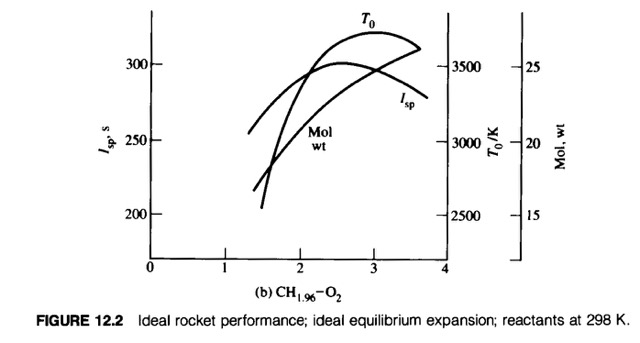

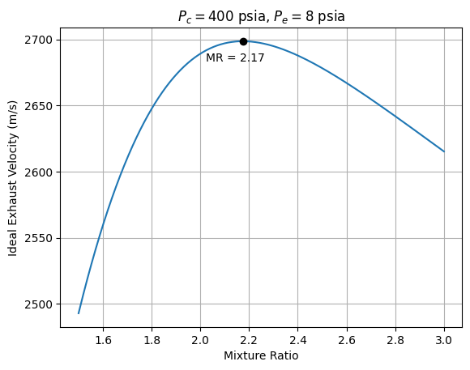

```python
Pc = 400 # psia
Pe = 8 # psia
MR = np.linspace(1.5, 3, 800)

Ve_ideal = np.zeros(len(MR))
for i in range(len(MR)):
   epsilon = rocket.get_eps_at_PcOvPe(Pc, MR[i], Pc/Pe, 1, 0)
   _, _, ae = rocket.get_SonicVelocities(Pc, MR[i], epsilon, 1, 0)
   Me = rocket.get_MachNumber(Pc, MR[i], epsilon, 1, 0)
   Ve_ideal[i] = ae*Me

plt.Figure
plt.plot(MR, Ve_ideal)
plt.xlabel("Mixture Ratio")
plt.ylabel("Ideal Exhaust Velocity (m/s)")
plt.grid(True)
max_Ve_ind = Ve_ideal.argmax()
plt.scatter(MR[max_Ve_ind], Ve_ideal[max_Ve_ind], c='k', zorder = 3)
plt.annotate((f"MR = {(MR[max_Ve_ind]):.2f}"),
             (MR[max_Ve_ind], Ve_ideal[max_Ve_ind]),
             (MR[max_Ve_ind]-0.15, Ve_ideal[max_Ve_ind]-15))
plt.title(f"$P_c = ${Pc} psia, $P_e = ${Pe} psia");
```

We have now established a wholistic approach for optimizing engine efficiency: instead of trying to strike a balance between $T_c$, $\gamma$, and $\epsilon$, we can just go directly to what it is we are trying to optimize. So what's the point of looking at $T_c$, $\gamma$, $\epsilon$, $C^*$, and $C_{\tau}$? It's because these variables provide direct insight into how altering our primary parameters change our engine. When testing, we want to know exactly what part of the engine is contributing to inefficiency, whether it's the injector, converging section, etc. Understanding the intermediate quantities gives us essential insight into what's actually improving or worsening our engine. That being said, if you're in a hurry, $V_e$ is a good way to go.

One key assumption that we've made during this analysis is that the engine is perfectly expanded. But in reality, the thrust output of the engine will be greatly affected by the ambient pressure:

$\tau = \dot{m}V_e + (P_e - P_{amb})A_e$

So in this regard, $V_e$ is not actually the thrust per unit mass flow unless the nozzle is perfectly expanded. The actual thrust per unit mass flow is called the *equivalent exhaust velocity* or *effective exhaust velocity*.

$V_{eq} = \frac{\tau}{\dot{m}} = V_e + \frac{(P_e - P_{amb})}{\dot{m}}A_e$

We can compare what $V_{eq}$ looks next to $V_e$ for the case of an overexpanded nozzle at sea-level ($P_e < P_{amb}$). Note that we don't know $A_e$ or $\dot{m}$, but we can use mass conservation and the ideal gas law to solve for $V_{eq}$ anyway.

$V_{eq} = V_e + \frac{(P_e - P_{amb})}{\dot{m}}A_e = V_e + \frac{(P_e - P_{amb})}{\rho_eV_e} = V_e + \frac{(P_e - P_{amb})RT_e}{P_eV_e}$

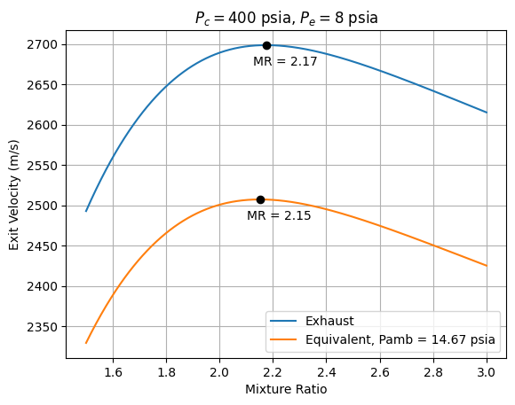

```python
Pamb = 14.67 # psia
Veq = np.zeros((len(MR)))
for i in range(len(MR)):
    epsilon = rocket.get_eps_at_PcOvPe(Pc, MR[i], Pc/Pe, 1, 0)
    _, _, Te = rocket.get_Temperatures(Pc, MR[i], epsilon, 1, 0)
    mc, _ = rocket.get_exit_MolWt_gamma(Pc, MR[i], epsilon, 1, 0)
    R = 8314/mc
    Veq[i] = Ve_ideal[i] + (Pe-Pamb)*R*Te/(Pe*Ve_ideal[i])
plt.Figure
plt.plot(MR, Ve_ideal, label = "Exhaust")
plt.xlabel("Mixture Ratio")
plt.ylabel("Exit Velocity (m/s)")
plt.grid(True)
plt.plot(MR, Veq, label = f'Equivalent, Pamb = {Pamb} psia')
plt.legend()
plt.scatter(MR[max_Ve_ind], Ve_ideal[max_Ve_ind], c='k', zorder = 3)
plt.annotate((f"MR = {(MR[max_Ve_ind]):.2f}"),
             (MR[max_Ve_ind], Ve_ideal[max_Ve_ind]),
             (MR[max_Ve_ind]-0.05, Ve_ideal[max_Ve_ind]-25))
max_eq_ind = Veq.argmax()
plt.scatter(MR[max_eq_ind], Veq[max_eq_ind], c='k', zorder = 3)
plt.annotate((f"MR = {(MR[max_eq_ind]):.2f}"),
             (MR[max_eq_ind], Veq[max_eq_ind]),
             (MR[max_eq_ind]-0.05, Veq[max_eq_ind]-25))
plt.title(f"$P_c = ${Pc} psia, $P_e = ${Pe} psia");
```

We can see that the ambient pressure actually decreases the $\frac{\tau}{\dot{m}}$ by an appreciable amount. Therefore, if we want to be completely accurate about our thrust per unit mass flow rate, we should be plotting the equivalent velocity. You'll notice, however, that the $V_{eq}$ is very similar to the $V_e$ curve but shifted down and slightly to the left. This can be understood by observing that the pressure term in $V_{eq} = V_e + \frac{(P_e - P_{amb})RT_e}{P_eV_e}$ becomes more negative as $P_{amb}$ increases.

Observe that $V_{eq}$ has the same units of $\frac{\tau}{\dot{m}}$, which has units of $\frac{N \cdot s}{kg}$, which are the units of momentum change (*impulse*) over mass. Essentially, $V_{eq}$ represents how much the instantaneous momentum of the rocket is changing due to thrust for every bit of propellant mixture mass that is used. Hence, this quantity $V_{eq}$ is often to referred to as the *specific impulse*, $I_{sp}$.

In typical application, $I_{sp}$ is actually defined as $\frac{V_{eq}}{g}$, where $g$ is the standard Earth gravitational acceleration at sea-level, just so that we get a better sense of how good the rocket is at breaking free from the constraints of gravity. Therefore, to summarize our discussion:

$C^*_{ideal}C_{\tau, ideal} = \frac{\tau}{\dot{m}} = V_e + \frac{(P_e - P_{amb})}{\dot{m}}A_e = V_{eq} = I_{sp}g$

This is why when people are talking about engine performace, $I_{sp}$ is a quantity that is guarunteed to come up. When it comes to actually sizing our rockets, we often care about the case in which we are perfectly expanded, so $V_{eq} = I_{sp}g = V_e$ anyway. This is usually the $I_{sp}$ value that is reported: the one at perfect expansion. But depending on the source, we have to be careful about how we interpret our $I_{sp}$. For example, sometimes the $I_{sp}$ is reported as the one at sea level, which, based on the plot above, would be less than the perfect expansion $I_{sp}$. Sometimes $I_{vac}$ is given instead of $I_{sp}$, which is the case in which $P_{amb} = 0$. When normalized by $g$, $I_{sp}$ will have units of *seconds*. NASA CEA, however, directly reports $V_{eq}$ as the $I_{sp}$, so neither the $I_{sp}$ nor the $I_{vac}$ in the NASA CEA output are normalized by $g$. In this case, the units will be the same units as velocity. RocketCEA does normalize the output by $g$.

Let's plot $I_{sp}$ vs $P_e$ to get a wholistic picture.

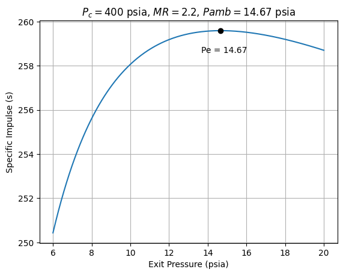

```python
MR = 2.2
Pe = np.linspace(6, 20, 400)

Isp = np.zeros(len(Pe))
for i, p in enumerate(Pe):
    eps = rocket.get_eps_at_PcOvPe(Pc, MR, Pc/p, 1, 0)
    Isp[i], _ = rocket.estimate_Ambient_Isp(Pc, MR, eps, Pamb, 1, 0)

plt.Figure
plt.plot(Pe, Isp)
plt.grid(True)
plt.xlabel("Exit Pressure (psia)")
plt.ylabel("Specific Impulse (s)")
ind = Isp.argmax()
plt.scatter(Pe[ind], Isp[ind], c='k', zorder = 3)
plt.annotate(f"Pe = {(Pe[ind]):.2f}", (Pe[ind], Isp[ind]),
             (Pe[ind]-1, Isp[ind]-1))
plt.title(f"$P_c = ${Pc} psia, $MR = ${MR}, $Pamb = ${Pamb} psia");
```

As we can see, for a given $MR$, the $I_{sp}$ is actually maximum when the engine is perfectly expanded for a given ambient pressure. This is the exit pressure for which the engine conventionally considered to be the most efficient. We will see this same idea in the next section. For now, it's important to understand that we have to be cognizant of the exit pressure we are designing to when we're choosing an $MR$ and nozzle shape to get the highest $I_{sp}$. This relationship between exit pressure and $I_{sp}$ at constant ambient pressure is one we will see later on too.

The key takeaway here is that for finding an optimal $MR$, everything we've discussed comes down to maximizing our $I_{sp}$ for a given set of parameters. Whether we choose to run at this optimal $MR$ depends primarily on our manufacturing capabilities.

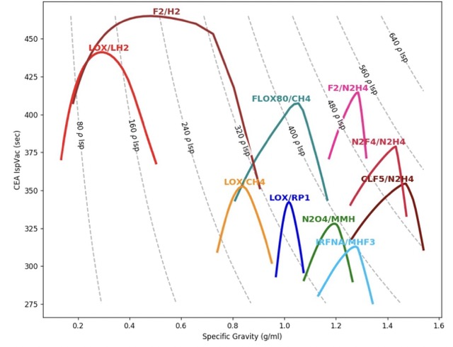

# $I_{sp}$ and $\tau$ for Varying Ambient Conditions

### What function (NASA CEA vs RocketCEA) gives the most realistic $I_{sp}$ and how does it inform nozzle design?

*get_Isp()* gives CEA's $I_{vac}$, which assumes an ambient pressure of 0. This value tends to greatly overestimate what would be measured at sea level. *estimate_Ambient_Isp()* gives $I_{sp}$ while accounting for losses due to over/underexpansion with sea level ambient pressure (by default), which is what is actually expected to be measured. However, this is not what NASA CEA gives as $I_{sp}$. For a given $P_e$ or expansion ratio, CEA assumes that the engine is at an altitude at which $P_e = P_{amb}$, meaning it is always perfectly expanded. This would also overshoot the expected $I_{sp}$ value, as a lower value is what would actually be measured at sea level. Hence, for $I_{sp}$ at sea level, the most accurate output would be:

*estimate_Ambient_Isp(Pc, MR, epsilon, Pamb = 14.7)*, where the $P_{amb} = 14.7$ psia is a default parameter.

CEA calculations maintain constant propellant consumption while allowing thrust to vary with ambient pressure as altitude increases instead of fixing the thrust and expecting a changing $\dot{m}$: the former case is more realistic. In the CEA case, the maximum thrust, and hence $I_{sp}$, would be achieved in a vaccuum for a given nozzle shape since $V_e$ remains constant, so the pressure-thrust term is maximized. This explains why $I_{vac}$ is always greater than $I_{sp}$ in CEA. Therefore:

*get_Isp() == $\frac{I_{vac, CEA}}{g}$ > estimate_Ambient_Isp(Pc, MR, epsilon, Pamb = Pe) == $\frac{I_{sp, CEA}}{g}$ > estimate_Ambient_Isp(Pc, MR, epsilon, Pamb = 14.7)*

Let's visual how ambient conditions affect our $I_{sp}$ over time, from Atlanta's altitude, which is about 1,050 above sea level, to about 200,000 ft above sea level.

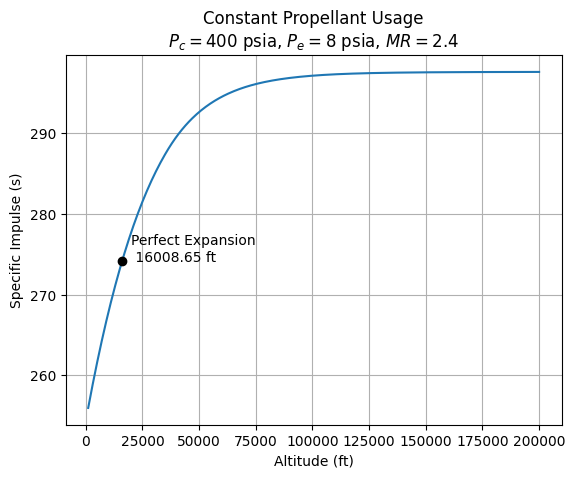

```python
Pc = 400 # psia
Pe = 8
altitude = np.linspace(1050, 200000, 400) # ft
MR = 2.4


h = altitude * 0.3048  # ft -> m
atm = Atmosphere(h) # initialize our Standard Atmosphere model
Pamb = atm.pressure / 6895  # Convert Pa to psia

Isp = np.zeros(len(Pamb))
epsilon = rocket.get_eps_at_PcOvPe(Pc, MR, Pc / Pe, frozen=1,
                                   frozenAtThroat=0)
for i, P in enumerate(Pamb):
    Isp[i], _ = rocket.estimate_Ambient_Isp(Pc, MR, epsilon,
                                            float(P), frozen=1,
                                            frozenAtThroat=0)

plt.figure()
plt.plot(altitude, Isp)
plt.ylabel("Specific Impulse (s)")
plt.xlabel("Altitude (ft)")
plt.grid(True)

ind = np.abs(Pamb - Pe).argmin()
plt.scatter(altitude[ind], Isp[ind], c='k', zorder=3)
plt.annotate((f"Perfect Expansion\n {(altitude[ind]):.2f} ft"),
             (altitude[ind], Isp[ind]),
             (altitude[ind] + 4000, Isp[ind]))

plt.title(f"Constant Propellant Usage\n$P_c = ${Pc} psia, $P_e = ${Pe} psia, $MR = ${MR}");
```

What does this plot tell us about how the thrust and mass flow rate? Checking back on the thrust equation:

$\tau = \dot{m}V_e + (P_e - P_{amb})A_e$

Because our nozzle and chamber conditions are fixed, $\dot{m}V_e$ is constant. Hence, $I_{sp}$ is increasing not because the $\dot{m}$ is decerasing at constant thrust, but because the thrust is increasing at constant $\dot{m}$. Clearly, being underexpanded ($P_e > P_{amb}$) gives more thrust, so then why are many engines overexpanded at sea level?

### Thrust vs. $P_e$

Let's fix our mass flow rate and see how thrust changes with $P_e$

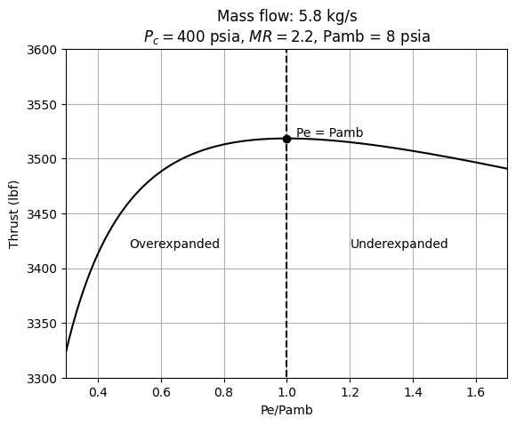

```python
mdot = 5.8 # kg/s
Pc = 400 # psia
MR = 2.2
Pamb = 8 # psia
Pe = np.linspace(1, 19, 600) # psia


T = np.zeros((len(Pe)))
Ve = np.zeros((len(Pe)))
T_p = np.zeros((len(Pe)))
for i in range(len(Pe)):
    epsilon = rocket.get_eps_at_PcOvPe(Pc, MR, Pc/Pe[i], 1, 0)
    _, _, ae = rocket.get_SonicVelocities(Pc, MR, epsilon, 1, 0)
    Me = rocket.get_MachNumber(Pc, MR, epsilon, 1, 0)
    Ve[i] = ae*Me
    _, _, Te = rocket.get_Temperatures(Pc, MR, epsilon, 1, 0)
    mc, _ = rocket.get_exit_MolWt_gamma(Pc, MR, epsilon, 1, 0)
    R = 8314 / mc
    A = R*Te*mdot / (Pe[i] * 6894.76 * Ve[i]) # exit area, psia --> Pa
    T[i] = (mdot*Ve[i] + (Pe[i] - Pamb)*A*6894.76)*0.224809 # N --> lbf
    T_p[i] = (Pe[i] - Pamb)*A*6894.76*0.224809 # pressure thrust

T_m = mdot*Ve*0.224809 # momentum thrust
plt.Figure
plt.plot(Pe/Pamb, T, c= 'k', label = 'Thrust')
plt.grid(True)
plt.ylabel("Thrust (lbf)")
plt.xlabel("Pe/Pamb")
plt.xlim([0.3, 1.7])
plt.ylim([3300, 3600])
ind = abs((Pe - Pamb)).argmin()
plt.scatter(Pe[ind]/Pamb, T[ind], c= 'k', zorder = 3)
plt.annotate("Pe = Pamb", (Pe[ind]/Pamb, T[ind]),
             (Pe[ind]/Pamb + 0.03, T[ind]+2))
plt.vlines(1, -100000, 100000, colors='k', linestyles='dashed')
plt.annotate(("Overexpanded"), (Pe[ind]/Pamb, T[ind]),
             (Pe[ind]/Pamb - 0.5, T[ind]-100))
plt.annotate(("Underexpanded"), (Pe[ind]/Pamb, T[ind]),
             (Pe[ind]/Pamb + 0.2, T[ind]-100))

plt.title(f"Mass flow: {mdot} kg/s\n$P_c = ${Pc} psia, $MR = ${MR}, Pamb = {Pamb} psia");
```

We should note that increasing $P_e$ is the same as decreasing the nozzle exit area, or shortening the nozzle, and that we are doing this at a constant altitude since $P_{amb}$ is constant. From this graph, we can see that as we vary nozzle size, we get the most thrust at the perfectly expanded case. Moreover, as we decrease nozzle size from the $P_e = P_{amb}$ case, the slope is less than on the other side of the line. To see why, we can isolate the two terms that contribute to thrust and observe each one individually.

```
Underexpanded Side: Momentum Thrust difference for a 6.01 psia Pe difference: -182.61 lbf
Underexpanded Side: Pressure Thrust difference for a 6.01 psia Pe difference: 151.86 lbf
Overexpanded Side: Momentum Thrust difference for a 4.00 psia Pe difference: -188.32 lbf
Overexpanded Side: Pressure Thrust difference for a 4.00 psia Pe difference: 245.97 lbf
```

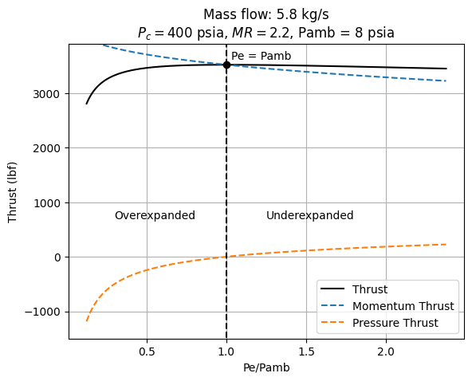

```python
plt.Figure
plt.plot(Pe/Pamb, T, c= 'k', label = 'Thrust')
plt.grid(True)
plt.plot(Pe/Pamb, T_m, '--', label= 'Momentum Thrust')
plt.plot(Pe/Pamb, T_p, '--', label='Pressure Thrust')
ind = abs((Pe - Pamb)).argmin()
plt.scatter(Pe[ind]/Pamb, T[ind], c= 'k', zorder = 3)
plt.annotate("Pe = Pamb", (Pe[ind]/Pamb, T[ind]), (Pe[ind]/Pamb + 0.03, T[ind]+100))
plt.ylabel("Thrust (lbf)")
plt.xlabel("Pe/Pamb")
#plt.xlim([0.5, 1.5])
plt.ylim([-1500, 3900])
plt.vlines(1, -100000, 100000, colors='k', linestyles='dashed')
plt.annotate(("Overexpanded"), (1, 100), (0.3, 700))
plt.annotate(("Underexpanded"), (1, 100), (1.25, 700))
plt.legend()

ind1 = abs((Pe - Pamb*0.50)).argmin()
ind2 = abs((Pe - Pamb*1.75)).argmin()
print(f"Underexpanded Side: Momentum Thrust difference for a {(Pe[ind2] - Pe[ind]):.2f} psia Pe difference: {(T_m[ind2] - T_m[ind]):.2f} lbf")
print(f"Underexpanded Side: Pressure Thrust difference for a {(Pe[ind2] - Pe[ind]):.2f} psia Pe difference: {(T_p[ind2] - T_p[ind]):.2f} lbf")
print(f"Overexpanded Side: Momentum Thrust difference for a {(Pe[ind] - Pe[ind1]):.2f} psia Pe difference: {(T_m[ind] - T_m[ind1]):.2f} lbf")
print(f"Overexpanded Side: Pressure Thrust difference for a {(Pe[ind] - Pe[ind1]):.2f} psia Pe difference: {(T_p[ind] - T_p[ind1]):.2f} lbf")
plt.title(f"Mass flow: {mdot} kg/s\n$P_c = ${Pc} psia, $MR = ${MR}, Pamb = {Pamb} psia");
```

We readily notice that most of the thrust actually comes from the momentum flux term. On the underexpanded side, we see that momentum thrust term is more sensitive to exit pressure changes while the pressure thrust is more sensitive on the overexpanded side. It seems that the pressure thrust is more sensitive to overexpansion than the momentum thrust is to under expansion. To get a better idea, it would be helpful to view the absolute value of the derivatives of the momentum and pressure thrust curves around the $P_e = P_{amb}$ point.

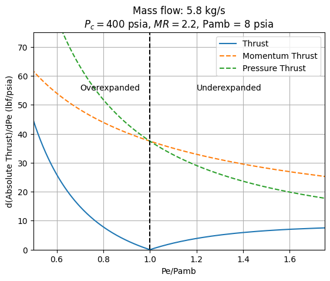

```python
dPe = min(np.diff(Pe))
dTm = np.gradient(T_m, dPe)
dTp = np.gradient(T_p, dPe)
dT = np.gradient(T, dPe)
plt.figure
plt.ylabel("d(Absolute Thrust)/dPe (lbf/psia)")
plt.xlabel("Pe/Pamb")
plt.plot(Pe/Pamb, np.abs(dT), label='Thrust')
plt.plot(Pe/Pamb, np.abs(dTm), '--', label = 'Momentum Thrust')
plt.plot(Pe/Pamb, np.abs(dTp), '--', label = 'Pressure Thrust')
plt.xlim([0.5, 1.75])
plt.ylim([0, 75])
plt.vlines(1, -1000, 1000, colors='k', linestyles='dashed')
plt.grid(True)
plt.annotate(("Overexpanded"), (1, 60), (0.7, 55))
plt.annotate(("Underexpanded"), (1, 60), (1.2, 55))
plt.legend()
plt.title(f"Mass flow: {mdot} kg/s\n$P_c = ${Pc} psia, $MR = ${MR}, Pamb = {Pamb} psia");
```

We can see that the momentum thrust tends to change more on the underexpanded side and the pressure thrust changes more on the overexpanded side. Using both plots, we can see that the engine is most "efficient" when it is perfectly expanded. That is, we didn't lose any thrust becuase we didn't expanded it enough or we expanded it too much. Keep in mind that this is not the same as the case in which we observed the $I_{sp}$ changes with altitude. In that scenario, the nozzle shape was kept the same as the ambient pressure changed. This means that the most efficient point on our $\tau$ vs $P_e$ curve is not necessarily the point of maximum thrust during flight.

That being said, how do we choose our exit pressure?

### What should our $P_e$ be and which set of ambient conditions should we use for design?

The answer to the first question is hardly simple and often comes down to a collaborative effort between all of the teams that work to design the vehicle. Sometimes the answer is easier to answer than at other times. For example, if your engine spends most of its time in the upper atmosphere or in space, you'de definitely want to size it so that it's close to perfectly expanded in space. (Perfectly expanded and not overexpanded because you lose some $\dot{m}V_e$ thrust by making the nozzle shorter). The would mean your engine is overexpanded at sea level. Sometimes your engine is operating on a staged vehicle, so it needs to fit in a certain envelope, meaning the nozzle exit area is limited. A lot of the times, your propellant becomes used up even before you reach the underexpanded region of your flight, making those higher thrusts unattainable. Maybe higher thrusts can lead to crazy structural loading at max Q.

To put it short, $P_e$ is determined by a trade studies involving propellant usage, structrual loading, and vehicle size constraints, so for the sake of engine design, we sometimes have to roll with an exit pressure. However, if we are given some freedom, we could examine how the optimal MR is affect by exit pressure.

For YJSP Fullscale sizing, we have been given an exit pressure of 8 psia and thrust of 3500 lbf to begin with. If we design to have 3500 lbf of thrust at sea level, we will require more mass flow rate to hit that thrust due to the effect of ambient back pressure. Therefore, to minimze the amount of propellant we use up, we will size by assuming that we will hit 3500 lbf of thrust when $P_e = P_{amb}$.

Another practical concern when choosing a $P_e$ is the possibility of flow separation.

#### Flow Separation

To understand the effects of flow separation, it's important to understand what occurs when a nozzle is overexanded or underexpanded. I recommend using Professor Seitzman's slides as a refresher: https://www.seitzman.gatech.edu/classes/ae2010/underoverexpanded.pdf

As a brief overview:

- **Underexpanded ($P_e > P_{amb}$):** to match the ambient pressure, the supersonic exhaust gases form Prandtl-Meyer Expansion waves
- **Overexpanded ($P_e < P_{amb}$):** to match the ambient pressure, the supersonic exhaust gases form Oblique Shock waves.

Both of these phenomena are repsonsible for the generation of *Mach Diamonds*, which is why we see them during HETS testing at sea level. In the case overexpansion, it's very possible that a shock wave, due to the extreme pressure difference between the pressure inside the nozzle and the ambient pressure, is pushed into the nozzle. This can be disasterous for a nozzle for two main reasons:

1. The sudden increase in pressure due to shock wave compression can create unfavorable structural loading mechanically and thermally
2. Since oblique shocks redirect the flow towards the radial center of the nozzle, they effectively reduce the exit area of the nozzle, reducing the thrust.

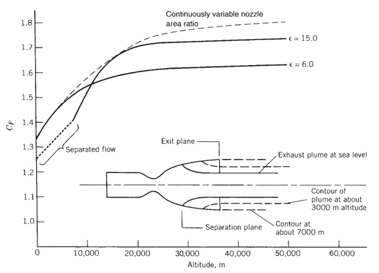

Predicting when flow separation occurs is not a simple as just seeing when $P_e < P_{amb}$, otherwise all overepxanded nozzles would separate. This is because of the *momentum boundary layer* that runs along the nozzle wall, a region of decreasing axial velocity due to friction between the flow gases and the nozzle wall. Therefore, the pressure in the boundary layer, being a non-isentropic flow, is not necessarily the same as that of the core flow. When a shock forms in the nozzle, the large adverse pressure gradient can cause the boundary layer to "detach" from the wall, redirecting the flow to the nozzle's centerline. Some of the flow will actually start to flow backwards since the high post-shock pressure acts almost like a wall. These two phenomena will greatly reduce the thrust. Flow separation during startup can cause very uneven pressure distributions along the engine walls, creating what are called *sideloads*, which can be disastrous during launch operations.

Being closer to formation of the oblique shocks, boundary layers are often the determining factor flow separation, but are also very difficult to model analytically. So, during preliminiary engine sizing, we can use a few a rules of thumb to figure out if our core flow exit pressure is low enough to cause separation.

The most common one is *Summerfield's criteria*:

$P_{amb} \ge (2.5)P_e$

Other common criteria include:

1. Schilling's critera: $\frac{P_e}{P_{amb}} = 0.583\left(\frac{P_c}{P_{amb}}\right)^{-0.195}$
2. Kate-Bendall criteria: $\frac{P_e}{P_{amb}} = \frac{2}{3}\left(\frac{P_c}{P_{amb}}\right)^{-0.2}$

Based on Summerfield's criteria, an exit pressure of 8 psia is well within the safe region: the highest ambient pressure we would ever get is 14.67 psia.

# Optimal MR vs Chamber Pressure

### Equilibrium or Frozen?

So far, in essentially every bit of code, I've used the assumption that the flow is fully frozen. These were the *1* and *0* in lines of code like *Isp[i], _ = rocket.estimate_Ambient_Isp(Pc, MR, epsilon, float(P), frozen=1, frozenAtThroat=0)* So what does frozen flow mean? What is shifting equilibrium flow?

As a refresher, thermodynamic equilibrium is when a given amount of substance does not appear to have any internal potentials that would cause the properties to shift over time. That means once a substance is at equilibrium, it wants to stay that way. When there are pressure or temperature differences within a fluid, the fluid will either exhibit bulk or molecular movement to reach equilibrium. This is why even though the flow inside a rocket engine is steady, it is not in thermodynamic equilibrium: there are pressure, temperature, AND chemical composition differences forcing the fluid to move from the chamber to the exit. However, if we isolate a tiny sliver of the gas flow, we can approimxate that differential fluid element as having a single pressure, temperature, and composition. Hence, equilibrium statistical mechanics and kinetics work in finding the approximate pressure, temperature, and chemical composition after the propellants react. This is exactly what CEA does.

With equilibrium flow, every differential element of the flow reaches an equilibrium chemical composition in accordance with the pressure and temperature of that element. With frozen flow, the propellants reach equilibrium on the theoretical injector face and then keep that chemical composition all the way through to the exit.

Choosing between equilibrium and frozen conditions is largely dependent on the chemical kinetics of the propellants that are chosen. The idea of reaction timescales plays a huge role in the shape of our nozzle. The speed at which the propellants react relative to how fast the propellants are flowing will inform the length and width of our chamber and converging section.

Some propellants (e.g. LH2/LOX) readily combine and therefore require relatively less time to react before being accelerated in the converging section. Other, bulkier propellants (e.g. RP-1/LOX) require more time in the chamber before being accelerated. This required *stay-time* of the propellants changes the required $L^*$. Moreover, if a combination of propellants requires fewer intermediate steps to combine and recombine, it is more likely to reach equilibrium *at each point along the nozzle*. This means that as the gases are flowing, some of the products will combine to form reactants again, regardless of how fast the bulk fluid motion is. In the opposite case, propellants whose reactions (*rate-limiting* reactions in particular) occur on longer timescales will tend to not recombine since they simply don't have enough time in the nozzle to do so. These types of propellants will be better modeled by **frozen** flow, especially for a smaller rocket engine like YJSP's. To be clear, there are different types of frozen flow. In general, frozen flow just means that some degree of freedom that existed in equilibrium flow no longer participates in the reactions. Sometimes that means the molecular compostion does not contribute to energy transfers, allowing only translation, rotation, and vibration to transfer momentum and energy. Other times, the vibrations of the molecules don't play a role in the reactions. The first step of most analysis processes is to examine the contribution of *chemically frozen* flow, which is was what CEA does.

For more information about this, I suggest reading Chapter 12.4 *NONEQUILIBRIUM EXPANSION* of **Mechanics and Thermodynamics of Propulsion, 2nd Edition** by Philip Hill and Carl Peterson

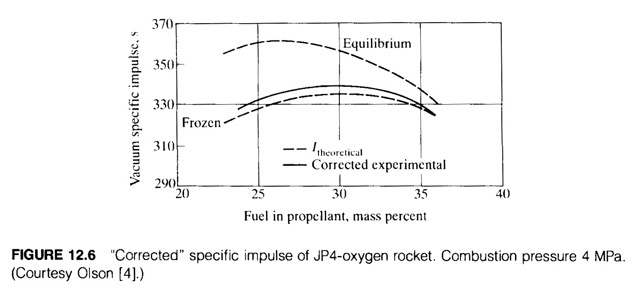

(JP-4 is an aviation-type kerosene similar to RP-1)

In reality, the flow is a mix of equilibrium and frozen with it, in general, tending from equilibrium to frozen from the chamber to the exit. This makes sense as the propellants do not have time to fully combine as the flow speeds up. There is one major benefit to assuming frozen or equilibrium for any section of the flow. From *Physical Gas Dynamics*, we see that for equilibrium and frozen flow, "we recover again the classical result that the change in velocity depends only on the net change in area ... Only in the two limits, however, does this simple result hold true... Because of the dependence of the nonequilibrium flow on its entire past history, it is not possible to find the mass flow in the supercritical case by proceeding at once to the throat, as can be done in equilibrium or frozen flow" (Vincenti, Kruger). Because neither equilibrium nor frozen flow sections depends on the flow that came before them in the nozzle, they can be modeled as entirely isentropic. This greatly simplifies our preliminary analysis.

Additionally, we should note that equilibrium flow represents the flow system with the greatest amount of energy release. This is because for a single temperature and pressure at a given axial station along the engine, when equilibrium is allowed, the species with the lowest enthalpies of formation will be the ones that tend to form, so more chemical energy can be extracted from molecular bonds into thermal energy. However, when the composition is enforced as frozen, the species will exist even if certain species would not form that $T$ and $p$. As a result, for a given set of engine parameters, the more equilibrium the flow, the higher the efficiency. This effect is called *kinetics efficiency* and is further discussed in the **Efficiencies** section.

Finding the exact characteristics of the flow would require complex kinetics calculations, which are usually done by **TDK (Two-dimensional kinetics)** (which is the JANNAF standard) or other softwares like RPA (Rocket Propulsion Analysis) or ANSYS Chemkin. These are expensive softwares and I'd rather not drop money on them so we will stick to CEA, which is more than accurate enough for the engines we build. CEA provides a few "combined" shfiting equilibrium and frozen composition models which are of interest:

- **Fully equilibrium**
- **NFZ = 1**: Frozen from the chamber
- **NFZ = 2**: Equilibrium up to the throat and frozen from the throat

(by the way NFZ stands for Nozzle Frozen Zone)

Instead of resorting to kinetics calculations, the best option is to compare with literature and historical data. Mechanics and Thermodynamics of Propulsion implies, "It is typical for freezing not to occur upstream of the throat; Timnat suggests that as a rough approximation one might assume shifting equilibrium to the throat, and frozen composition thereafter"(580). This backs up the claim that RP-1/LOX is better modeled by a non-equilibrium approach, but the statement itself is quite vague and could apply to engines of any size. The following website:

http://www.braeunig.us/space/comb.htm

provides a chart of optimal mixture ratio as a function of chamber pressure for $P_e = 0.1$ atm and $1$ atm. I have taken the data and converted it into psi so that it is easier to compare with.

### Load Propellant Chart Data

```python
# Pc vs MR for 1 atm
Pc_MR_1 = np.array([
    [7.125468646160279, 2.100554009728027],
    [8.53779257080489, 2.1093292630446165],
    [9.560093571825284, 2.11876277846918],
    [10.325966311485764, 2.1263753120336464],
    [11.35115442701482, 2.133989945317755],
    [12.376867472454542, 2.141273872758145],
    [13.659621197483304, 2.149992958574293],
    [15.200815415196217, 2.1592653205162824],
    [16.743759399278012, 2.1674353296458753],
    [18.287053336633583, 2.1753848682129884],
    [19.960829851783075, 2.182815776028364],
    [21.764489024828563, 2.190106002627682],
    [23.696456066038053, 2.1982476655420986],
    [25.758905685041483, 2.205870697704778],
    [27.951129643070445, 2.213421289539786],
    [30.532618292630445, 2.2207913054855246],
    [33.37353896915029, 2.228089930963413],
    [36.214459645670146, 2.2353885564413014],
    [39.055762089397746, 2.242446668578303],
    [41.89830527655056, 2.2487231123574234],
    [44.74137339361404, 2.254668850292825],
    [47.585348207795946, 2.2600433690436206],
    [50.43056376540305, 2.264636219436535],
    [53.27558843940628, 2.2693493264998925],
    [56.12037450890466, 2.2742127544013044],
    [58.96511285750208, 2.279106246470327],
    [61.81028069420822, 2.283729161030852],
    [64.6566415534386, 2.2876004714011065],
    [67.50262064546122, 2.291712295112248],
    [70.34859973748384, 2.295824118823389],
    [73.19429250410064, 2.300116327540195],
    [76.04060564243005, 2.3040177020780606],
    [78.88839812868952, 2.3069870874199903],
    [81.73504531332571, 2.31067801278458],
    [84.58245603237744, 2.3138879114673965],
    [87.42948498422139, 2.3173383234910996],
    [90.27732519138182, 2.3202776446654187],
    [93.12502223583935, 2.3233071583425704],
    [95.972528396693, 2.326456928690165],
    [98.82041632475439, 2.3293661856968733],
    [101.66868602002357, 2.332034929362695],
    [104.51733748250048, 2.33446315968763],
    [107.36594122407642, 2.336921454180176],
    [110.2144972447514, 2.3394098128403327],
    [113.06310098632737, 2.3418681073328784],
    [115.91175244880425, 2.3442963376578136],
    [118.76073795758798, 2.346514118809473],
    [121.60962802456974, 2.348792028296354],
    [124.45823176614569, 2.3512503227889],
    [127.3070263913255, 2.3535883606110026],
    [130.15672771362375, 2.3553551792484995],
    [133.00595182691228, 2.3574226395621047],
    [135.85493733569604, 2.359640420713764],
    [138.70349335637098, 2.3621287793739207],
    [141.5540059339857, 2.3633845071620336],
    [144.4032300472743, 2.365451967475639],
    [147.25264504416674, 2.367399171118801],
    [150.10244180826692, 2.369105861421076],
    [152.95262033957482, 2.370572038382465],
    [155.80260798727892, 2.372158472014297],
    [158.65164121696358, 2.3743461889983455],
    [161.5012470974599, 2.3761731359710643],
    [164.35028032714456, 2.3783608529551126],
    [167.20007709124474, 2.380067543257388],
    [170.05063738976048, 2.3812932068778903],
    [172.9015794554839, 2.3822783571575057],
    [175.7513284986831, 2.384015111627392],
    [178.60136386728817, 2.3855714810916133],
    [181.45077886418062, 2.387518684734775],
    [184.30095739548852, 2.388984861696164],
    [187.1507541595887, 2.3906915519984393],
    [190.00093269089666, 2.392157728959828],
    [192.85106350130366, 2.3936539700888275],
    [195.70114659080969, 2.395180275385438],
    [198.55127740121662, 2.3966765165144377],
    [201.4018376997323, 2.39790218013494],
    [204.25230255644607, 2.3991879720906635],
    [207.10281513406085, 2.400443699878777],
    [209.95327999077455, 2.4017294918345007],
    [212.80388801019126, 2.4029250912873916],
    [215.65449602960797, 2.404120690740283],
    [218.5050563281236, 2.4053463543607854],
    [221.35556890573838, 2.4066020821488983],
    [224.20617692515503, 2.4077976816017896],
    [227.05668950276976, 2.4090534093899025],
    [229.90724980128545, 2.410279073010405],
    [232.75781009980113, 2.4115047366309073],
    [235.60837039831688, 2.412730400251409],
    [238.45893069683257, 2.4139560638719115],
    [241.30968187895212, 2.4150614708219704],
    [244.1602421774678, 2.4162871344424723],
    [247.01080247598355, 2.4175127980629747],
    [249.21421963645105, 2.4180116723617107]])

# Pc vs MR for 0.1 atm
Pc_MR_01 = np.array([
    [7.097559872576575, 2.1453650015052323],
    [8.466467719193261, 2.1542639195599427],
    [9.488703103974828, 2.163738773214971],
    [10.341189278895051, 2.171241771404745],
    [11.278189169432359, 2.1799580575947033],
    [12.303377284961414, 2.187572690878812],
    [13.457698158514106, 2.195519079866461],
    [14.741886691965355, 2.203334236376444],
    [16.155487946059253, 2.2113047721399837],
    [17.6991318366886, 2.2190338401446175],
    [19.5012162200021, 2.2273161842750926],
    [21.563140909094855, 2.235269922281491],
    [23.625131214426432, 2.2431823220574247],
    [25.946410649131067, 2.251113356845187],
    [28.267545728110278, 2.259135335739972],
    [30.719493340827242, 2.266430811638396],
    [33.561750202574245, 2.2728876404231815],
    [36.4034344135096, 2.2797052392192967],
    [39.24492774084109, 2.2866430946858554],
    [42.08742320709294, 2.2929496026325866],
    [44.93044360325544, 2.2989254047355985],
    [47.77451385923928, 2.304239795151173],
    [50.62001574225221, 2.3086522605384223],
    [53.464849532651556, 2.3134856242722233],
    [56.31025597386255, 2.3179582179946943],
    [59.156187344984204, 2.3221001058734463],
    [62.00188011160101, 2.3263923145902523],
    [64.84814552902945, 2.3303237532957284],
    [67.69422006285401, 2.334375448671648],
    [70.54010371307469, 2.338547400718011],
    [73.38598736329537, 2.3427193527643735],
    [76.23230050162478, 2.346620727302239],
    [79.07990210428036, 2.349710369314612],
    [81.92678789342142, 2.353250973841148],
    [84.77410317067121, 2.356521000859186],
    [87.62156161062386, 2.3597008353743916],
    [90.46944953868528, 2.3626100923810998],
    [93.31771923395443, 2.3652788360469215],
    [96.16598892922362, 2.367947579712743],
    [99.01387685728498, 2.3708568367194514],
    [101.86252831976192, 2.3732850670443866],
    [104.71117978223883, 2.3757132973693214],
    [107.55983124471577, 2.3781415276942566],
    [110.40843498629168, 2.3805998221868023],
    [113.25699100696669, 2.3830881808469595],
    [116.10559474854263, 2.3855464753395053],
    [118.95462797822732, 2.3877341923235536],
    [121.80361348701099, 2.3899519734752133],
    [124.652169507686, 2.3924403321353696],
    [127.50077324926194, 2.3948986266279157],
    [130.350760896966, 2.3964850602597476],
    [133.1997464057497, 2.398702841411407],
    [136.04877963543436, 2.4008905583954556],
    [138.89752653971323, 2.403258660385169],
    [141.74808683822891, 2.4044843240056712],
    [144.5970723470126, 2.4067021051573305],
    [147.44667822750893, 2.4085290521300493],
    [150.2964749916091, 2.4102357424323246],
    [153.14665352291706, 2.4117019193937135],
    [155.99645028701724, 2.413408609695989],
    [158.84567440030582, 2.4154760700095936],
    [161.69542344350504, 2.41721282447948],
    [164.54569741661493, 2.4186188731056473],
    [167.39582822702187, 2.4201151142346466],
    [170.24581587472596, 2.421701547866479],
    [173.09561263882614, 2.4234082381687543],
    [175.9457911701341, 2.4248744151301427],
    [178.795969701442, 2.4263405920915315],
    [181.64652999995775, 2.427566255712034],
    [184.49670853126565, 2.4290324326734227],
    [187.34688706257361, 2.430498609634811],
    [190.1970178729806, 2.431994850763811],
    [193.04710096248658, 2.4335211560604213],
    [195.89723177289358, 2.435017397189421],
    [198.74741030420154, 2.4364835741508095],
    [201.59758883550944, 2.4379497511121984],
    [204.4481491340252, 2.4391754147327007],
    [207.2983276653331, 2.4406415916940896],
    [210.14850619664105, 2.442107768655478],
    [212.9990664951568, 2.4433334322759803],
    [215.8492450264647, 2.444799609237369],
    [218.69942355777266, 2.446265786198758],
    [221.54998385628835, 2.44749144981926],
    [224.40021010849728, 2.448927562613038],
    [227.25067496521098, 2.4502133545687617],
    [230.10123526372672, 2.451439018189264],
    [232.95184328314338, 2.4526346176421554],
    [235.8024513025601, 2.453830217095047],
    [238.65315476377862, 2.454965688212716],
    [241.50376278319533, 2.4561612876656076],
    [244.35427536081005, 2.457417015453721],
    [247.2048356593258, 2.458642679074223],
    [249.27878601546286, 2.459020246842694]])
```